# Predicting the Success of a Movie

### Contributors: Donald Fung, Justin Shaw, Jennifer Koh

[figure not shown]

## Outline

- 1. Introduction
- 2. Data Collection
- 3. Data Tidying
- 4. How does budget affect the success of a movie?
  - 4.1 What budget range has the most positive effect on movies?
- 5. Does runtime have a significant affect on total revenue?
  - 5.1 What runtimes have the most positive effect on movies?
- 6. Do genres significantly impact movie success?
  - 6.1 What genres have the most positive effect on movies?
- 7. How do ratings effect a movies revenue?
  - 7.1 What ratings have the most positive effect on movies?
- 8. What release months yield more successful movies?
  - 8.1 What time of year has the most positive effect on movies?
- 9. Can we build an accurate model that accurately predicts a movies' success?
- 10. Conclusion

# 1. Introduction

The overall objective of this project is to analyze movies from the 1900s to 2017 to try and determine what factors have the most impact on a successful movie. In this sense, we defined "success" as how much money a particular movie grossed internatally. Then, by analyzing several key characteristics of each movie and comparing them to worldwide gross, we can look for correlations between these factors and success. Using this data, we determine the ideal characteristics a successful movie should have and also attempt to create a model that predicts the success of a movie.

The first step is to import all the different libraries we will need to use throughout this project.

```python
import pandas as pd
import re
import seaborn as sns
import matplotlib.pyplot as plt
import numpy as np
from sklearn import linear_model
```

# 2. Data Collection

The first step is to collect the data. We obtained data seen below on movies released between the 1900s and 2017 as a CSV file from Kaggle. A link to this data can be found [here](https://www.kaggle.com/rounakbanik/the-movies-dataset).

```python
data = pd.read_csv('movies_metadata.csv')
data
```

|  | adult | belongs_to_collection | budget | genres | homepage | id | imdb_id | original_language | original_title | overview | ... | release_date | revenue | runtime | spoken_languages | status | tagline | title | video | vote_average | vote_count |
| --- | --- | --- | --- | --- | --- | --- | --- | --- | --- | --- | --- | --- | --- | --- | --- | --- | --- | --- | --- | --- | --- |
| 0 | False | {'id': 10194, 'name': 'Toy Story Collection', ... | 30000000 | [{'id': 16, 'name': 'Animation'}, {'id': 35, '... | http://toystory.disney.com/toy-story | 862 | tt0114709 | en | Toy Story | Led by Woody, Andy's toys live happily in his ... | ... | 1995-10-30 | 373554033.0 | 81.0 | [{'iso_639_1': 'en', 'name': 'English'}] | Released | NaN | Toy Story | False | 7.7 | 5415.0 |
| 1 | False | NaN | 65000000 | [{'id': 12, 'name': 'Adventure'}, {'id': 14, '... | NaN | 8844 | tt0113497 | en | Jumanji | When siblings Judy and Peter discover an encha... | ... | 1995-12-15 | 262797249.0 | 104.0 | [{'iso_639_1': 'en', 'name': 'English'}, {'iso... | Released | Roll the dice and unleash the excitement! | Jumanji | False | 6.9 | 2413.0 |
| 2 | False | {'id': 119050, 'name': 'Grumpy Old Men Collect... | 0 | [{'id': 10749, 'name': 'Romance'}, {'id': 35, ... | NaN | 15602 | tt0113228 | en | Grumpier Old Men | A family wedding reignites the ancient feud be... | ... | 1995-12-22 | 0.0 | 101.0 | [{'iso_639_1': 'en', 'name': 'English'}] | Released | Still Yelling. Still Fighting. Still Ready for... | Grumpier Old Men | False | 6.5 | 92.0 |
| 3 | False | NaN | 16000000 | [{'id': 35, 'name': 'Comedy'}, {'id': 18, 'nam... | NaN | 31357 | tt0114885 | en | Waiting to Exhale | Cheated on, mistreated and stepped on, the wom... | ... | 1995-12-22 | 81452156.0 | 127.0 | [{'iso_639_1': 'en', 'name': 'English'}] | Released | Friends are the people who let you be yourself... | Waiting to Exhale | False | 6.1 | 34.0 |
| 4 | False | {'id': 96871, 'name': 'Father of the Bride Col... | 0 | [{'id': 35, 'name': 'Comedy'}] | NaN | 11862 | tt0113041 | en | Father of the Bride Part II | Just when George Banks has recovered from his ... | ... | 1995-02-10 | 76578911.0 | 106.0 | [{'iso_639_1': 'en', 'name': 'English'}] | Released | Just When His World Is Back To Normal... He's ... | Father of the Bride Part II | False | 5.7 | 173.0 |
| 5 | False | NaN | 60000000 | [{'id': 28, 'name': 'Action'}, {'id': 80, 'nam... | NaN | 949 | tt0113277 | en | Heat | Obsessive master thief, Neil McCauley leads a ... | ... | 1995-12-15 | 187436818.0 | 170.0 | [{'iso_639_1': 'en', 'name': 'English'}, {'iso... | Released | A Los Angeles Crime Saga | Heat | False | 7.7 | 1886.0 |
| 6 | False | NaN | 58000000 | [{'id': 35, 'name': 'Comedy'}, {'id': 10749, '... | NaN | 11860 | tt0114319 | en | Sabrina | An ugly duckling having undergone a remarkable... | ... | 1995-12-15 | 0.0 | 127.0 | [{'iso_639_1': 'fr', 'name': 'Français'}, {'is... | Released | You are cordially invited to the most surprisi... | Sabrina | False | 6.2 | 141.0 |
| 7 | False | NaN | 0 | [{'id': 28, 'name': 'Action'}, {'id': 12, 'nam... | NaN | 45325 | tt0112302 | en | Tom and Huck | A mischievous young boy, Tom Sawyer, witnesses... | ... | 1995-12-22 | 0.0 | 97.0 | [{'iso_639_1': 'en', 'name': 'English'}, {'iso... | Released | The Original Bad Boys. | Tom and Huck | False | 5.4 | 45.0 |
| 8 | False | NaN | 35000000 | [{'id': 28, 'name': 'Action'}, {'id': 12, 'nam... | NaN | 9091 | tt0114576 | en | Sudden Death | International action superstar Jean Claude Van... | ... | 1995-12-22 | 64350171.0 | 106.0 | [{'iso_639_1': 'en', 'name': 'English'}] | Released | Terror goes into overtime. | Sudden Death | False | 5.5 | 174.0 |
| 9 | False | {'id': 645, 'name': 'James Bond Collection', '... | 58000000 | [{'id': 12, 'name': 'Adventure'}, {'id': 28, '... | http://www.mgm.com/view/movie/757/Goldeneye/ | 710 | tt0113189 | en | GoldenEye | James Bond must unmask the mysterious head of ... | ... | 1995-11-16 | 352194034.0 | 130.0 | [{'iso_639_1': 'en', 'name': 'English'}, {'iso... | Released | No limits. No fears. No substitutes. | GoldenEye | False | 6.6 | 1194.0 |
| 10 | False | NaN | 62000000 | [{'id': 35, 'name': 'Comedy'}, {'id': 18, 'nam... | NaN | 9087 | tt0112346 | en | The American President | Widowed U.S. president Andrew Shepherd, one of... | ... | 1995-11-17 | 107879496.0 | 106.0 | [{'iso_639_1': 'en', 'name': 'English'}] | Released | Why can't the most powerful man in the world h... | The American President | False | 6.5 | 199.0 |
| 11 | False | NaN | 0 | [{'id': 35, 'name': 'Comedy'}, {'id': 27, 'nam... | NaN | 12110 | tt0112896 | en | Dracula: Dead and Loving It | When a lawyer shows up at the vampire's doorst... | ... | 1995-12-22 | 0.0 | 88.0 | [{'iso_639_1': 'en', 'name': 'English'}, {'iso... | Released | NaN | Dracula: Dead and Loving It | False | 5.7 | 210.0 |
| 12 | False | {'id': 117693, 'name': 'Balto Collection', 'po... | 0 | [{'id': 10751, 'name': 'Family'}, {'id': 16, '... | NaN | 21032 | tt0112453 | en | Balto | An outcast half-wolf risks his life to prevent... | ... | 1995-12-22 | 11348324.0 | 78.0 | [{'iso_639_1': 'en', 'name': 'English'}] | Released | Part Dog. Part Wolf. All Hero. | Balto | False | 7.1 | 423.0 |
| 13 | False | NaN | 44000000 | [{'id': 36, 'name': 'History'}, {'id': 18, 'na... | NaN | 10858 | tt0113987 | en | Nixon | An all-star cast powers this epic look at Amer... | ... | 1995-12-22 | 13681765.0 | 192.0 | [{'iso_639_1': 'en', 'name': 'English'}] | Released | Triumphant in Victory, Bitter in Defeat. He Ch... | Nixon | False | 7.1 | 72.0 |
| 14 | False | NaN | 98000000 | [{'id': 28, 'name': 'Action'}, {'id': 12, 'nam... | NaN | 1408 | tt0112760 | en | Cutthroat Island | Morgan Adams and her slave, William Shaw, are ... | ... | 1995-12-22 | 10017322.0 | 119.0 | [{'iso_639_1': 'en', 'name': 'English'}, {'iso... | Released | The Course Has Been Set. There Is No Turning B... | Cutthroat Island | False | 5.7 | 137.0 |
| 15 | False | NaN | 52000000 | [{'id': 18, 'name': 'Drama'}, {'id': 80, 'name... | NaN | 524 | tt0112641 | en | Casino | The life of the gambling paradise – Las Vegas ... | ... | 1995-11-22 | 116112375.0 | 178.0 | [{'iso_639_1': 'en', 'name': 'English'}] | Released | No one stays at the top forever. | Casino | False | 7.8 | 1343.0 |
| 16 | False | NaN | 16500000 | [{'id': 18, 'name': 'Drama'}, {'id': 10749, 'n... | NaN | 4584 | tt0114388 | en | Sense and Sensibility | Rich Mr. Dashwood dies, leaving his second wif... | ... | 1995-12-13 | 135000000.0 | 136.0 | [{'iso_639_1': 'en', 'name': 'English'}] | Released | Lose your heart and come to your senses. | Sense and Sensibility | False | 7.2 | 364.0 |
| 17 | False | NaN | 4000000 | [{'id': 80, 'name': 'Crime'}, {'id': 35, 'name... | NaN | 5 | tt0113101 | en | Four Rooms | It's Ted the Bellhop's first night on the job.... | ... | 1995-12-09 | 4300000.0 | 98.0 | [{'iso_639_1': 'en', 'name': 'English'}] | Released | Twelve outrageous guests. Four scandalous requ... | Four Rooms | False | 6.5 | 539.0 |
| 18 | False | {'id': 3167, 'name': 'Ace Ventura Collection',... | 30000000 | [{'id': 80, 'name': 'Crime'}, {'id': 35, 'name... | NaN | 9273 | tt0112281 | en | Ace Ventura: When Nature Calls | Summoned from an ashram in Tibet, Ace finds hi... | ... | 1995-11-10 | 212385533.0 | 90.0 | [{'iso_639_1': 'en', 'name': 'English'}] | Released | New animals. New adventures. Same hair. | Ace Ventura: When Nature Calls | False | 6.1 | 1128.0 |
| 19 | False | NaN | 60000000 | [{'id': 28, 'name': 'Action'}, {'id': 35, 'nam... | NaN | 11517 | tt0113845 | en | Money Train | A vengeful New York transit cop decides to ste... | ... | 1995-11-21 | 35431113.0 | 103.0 | [{'iso_639_1': 'en', 'name': 'English'}] | Released | Get on, or GET OUT THE WAY! | Money Train | False | 5.4 | 224.0 |
| 20 | False | {'id': 91698, 'name': 'Chili Palmer Collection... | 30250000 | [{'id': 35, 'name': 'Comedy'}, {'id': 53, 'nam... | NaN | 8012 | tt0113161 | en | Get Shorty | Chili Palmer is a Miami mobster who gets sent ... | ... | 1995-10-20 | 115101622.0 | 105.0 | [{'iso_639_1': 'en', 'name': 'English'}] | Released | The mob is tough, but it’s nothing like show b... | Get Shorty | False | 6.4 | 305.0 |
| 21 | False | NaN | 0 | [{'id': 18, 'name': 'Drama'}, {'id': 53, 'name... | NaN | 1710 | tt0112722 | en | Copycat | An agoraphobic psychologist and a female detec... | ... | 1995-10-27 | 0.0 | 124.0 | [{'iso_639_1': 'en', 'name': 'English'}, {'iso... | Released | One man is copying the most notorious killers ... | Copycat | False | 6.5 | 199.0 |
| 22 | False | NaN | 50000000 | [{'id': 28, 'name': 'Action'}, {'id': 12, 'nam... | NaN | 9691 | tt0112401 | en | Assassins | Assassin Robert Rath arrives at a funeral to k... | ... | 1995-10-06 | 30303072.0 | 132.0 | [{'iso_639_1': 'en', 'name': 'English'}, {'iso... | Released | In the shadows of life, In the business of dea... | Assassins | False | 6.0 | 394.0 |
| 23 | False | NaN | 0 | [{'id': 18, 'name': 'Drama'}, {'id': 14, 'name... | NaN | 12665 | tt0114168 | en | Powder | Harassed by classmates who won't accept his sh... | ... | 1995-10-27 | 0.0 | 111.0 | [{'iso_639_1': 'en', 'name': 'English'}] | Released | An extraordinary encounter with another human ... | Powder | False | 6.3 | 143.0 |
| 24 | False | NaN | 3600000 | [{'id': 18, 'name': 'Drama'}, {'id': 10749, 'n... | http://www.mgm.com/title_title.do?title_star=L... | 451 | tt0113627 | en | Leaving Las Vegas | Ben Sanderson, an alcoholic Hollywood screenwr... | ... | 1995-10-27 | 49800000.0 | 112.0 | [{'iso_639_1': 'en', 'name': 'English'}] | Released | I Love You... The Way You Are. | Leaving Las Vegas | False | 7.1 | 365.0 |
| 25 | False | NaN | 0 | [{'id': 18, 'name': 'Drama'}] | NaN | 16420 | tt0114057 | en | Othello | The evil Iago pretends to be friend of Othello... | ... | 1995-12-15 | 0.0 | 123.0 | [{'iso_639_1': 'en', 'name': 'English'}] | Released | Envy, greed, jealousy and love. | Othello | False | 7.0 | 33.0 |
| 26 | False | NaN | 12000000 | [{'id': 35, 'name': 'Comedy'}, {'id': 18, 'nam... | NaN | 9263 | tt0114011 | en | Now and Then | Waxing nostalgic about the bittersweet passage... | ... | 1995-10-20 | 27400000.0 | 100.0 | [{'iso_639_1': 'en', 'name': 'English'}] | Released | In every woman there is the girl she left behind. | Now and Then | False | 6.6 | 91.0 |
| 27 | False | NaN | 0 | [{'id': 18, 'name': 'Drama'}, {'id': 10749, 'n... | NaN | 17015 | tt0114117 | en | Persuasion | This film adaptation of Jane Austen's last nov... | ... | 1995-09-27 | 0.0 | 104.0 | [{'iso_639_1': 'en', 'name': 'English'}] | Released | NaN | Persuasion | False | 7.4 | 36.0 |
| 28 | False | NaN | 18000000 | [{'id': 14, 'name': 'Fantasy'}, {'id': 878, 'n... | NaN | 902 | tt0112682 | fr | La Cité des Enfants Perdus | A scientist in a surrealist society kidnaps ch... | ... | 1995-05-16 | 1738611.0 | 108.0 | [{'iso_639_1': 'cn', 'name': '广州话 / 廣州話'}, {'i... | Released | Where happily ever after is just a dream. | The City of Lost Children | False | 7.6 | 308.0 |
| 29 | False | NaN | 0 | [{'id': 18, 'name': 'Drama'}, {'id': 80, 'name... | NaN | 37557 | tt0115012 | zh | 摇啊摇，摇到外婆桥 | A provincial boy related to a Shanghai crime f... | ... | 1995-04-30 | 0.0 | 108.0 | [{'iso_639_1': 'zh', 'name': '普通话'}] | Released | In 1930's Shanghai violence was not the proble... | Shanghai Triad | False | 6.5 | 17.0 |
| ... | ... | ... | ... | ... | ... | ... | ... | ... | ... | ... | ... | ... | ... | ... | ... | ... | ... | ... | ... | ... | ... |
| 45436 | False | NaN | 0 | [{'id': 28, 'name': 'Action'}, {'id': 9648, 'n... | NaN | 45527 | tt1331329 | en | The Final Storm | A stranger named Silas flees from a devastatin... | ... | 2010-01-01 | 0.0 | 92.0 | [{'iso_639_1': 'en', 'name': 'English'}] | Released | Action, Horror | The Final Storm | False | 3.7 | 11.0 |
| 45437 | False | NaN | 0 | [{'id': 10751, 'name': 'Family'}, {'id': 16, '... | NaN | 455661 | tt6969946 | en | In a Heartbeat | A closeted boy runs the risk of being outed by... | ... | 2017-06-01 | 0.0 | 4.0 | [{'iso_639_1': 'en', 'name': 'English'}] | Released | The Heart Wants What The Heart Wants | In a Heartbeat | False | 8.3 | 146.0 |
| 45438 | False | NaN | 0 | [{'id': 18, 'name': 'Drama'}] | NaN | 327237 | tt3814486 | nl | Bloed, Zweet en Tranen | Bloed, Zweet en Tranen (Blood, Sweat and Tears... | ... | 2015-04-02 | 0.0 | 111.0 | [{'iso_639_1': 'nl', 'name': 'Nederlands'}] | Released | The movie about Andre Hazes | Blood, Sweat and Tears | False | 6.8 | 11.0 |
| 45439 | False | NaN | 0 | [{'id': 18, 'name': 'Drama'}, {'id': 14, 'name... | NaN | 84710 | tt0036975 | en | Jungle Woman | Paula the ape woman (Acquanetta) is alive and ... | ... | 1944-06-01 | 0.0 | 61.0 | [{'iso_639_1': 'en', 'name': 'English'}] | Released | RAPTUROUS BEAUTY!...FURY OF A BEAST! | Jungle Woman | False | 5.8 | 2.0 |
| 45440 | False | NaN | 0 | [{'id': 18, 'name': 'Drama'}, {'id': 10751, 'n... | NaN | 39562 | tt0889600 | en | To Be Fat Like Me | Pretty, popular, and slim high-schooler Aly Sc... | ... | 2007-01-08 | 0.0 | 89.0 | [{'iso_639_1': 'en', 'name': 'English'}] | Released | NaN | To Be Fat Like Me | False | 5.0 | 12.0 |
| 45441 | False | NaN | 0 | [{'id': 35, 'name': 'Comedy'}] | NaN | 14008 | tt0294425 | en | Cadet Kelly | Hyperactive teenager Kelly is enrolled into a ... | ... | 2002-03-07 | 0.0 | 101.0 | [{'iso_639_1': 'en', 'name': 'English'}] | Released | Too Cool For The Rules! | Cadet Kelly | False | 5.2 | 145.0 |
| 45442 | False | NaN | 0 | [] | NaN | 44330 | tt0135690 | en | Le tripot clandestin | A combination gambling den and bawdy house is ... | ... | 1905-01-01 | 0.0 | 3.0 | [] | NaN | NaN | The Scheming Gambler's Paradise | False | 5.0 | 3.0 |
| 45443 | False | NaN | 0 | [{'id': 35, 'name': 'Comedy'}, {'id': 14, 'nam... | NaN | 49279 | tt0000359 | fr | L'Homme à la tête de caoutchouc | A chemist in his laboratory places upon a tabl... | ... | 1901-01-01 | 0.0 | 3.0 | [] | Released | NaN | The Man with the Rubber Head | False | 7.6 | 29.0 |
| 45444 | False | NaN | 0 | [{'id': 14, 'name': 'Fantasy'}] | NaN | 44333 | tt0135179 | fr | Les cartes vivantes | A bearded magician holds up a large playing ca... | ... | 1905-01-01 | 0.0 | 3.0 | [{'iso_639_1': 'xx', 'name': 'No Language'}] | Released | NaN | The Living Playing Cards | False | 6.1 | 8.0 |
| 45445 | False | NaN | 0 | [{'id': 14, 'name': 'Fantasy'}, {'id': 35, 'na... | NaN | 49277 | tt0135122 | en | Les affiches en goguette | A wall full of advertising posters comes to life. | ... | 1906-01-01 | 0.0 | 3.0 | [{'iso_639_1': 'fr', 'name': 'Français'}, {'is... | Released | NaN | The Hilarious Posters | False | 4.5 | 2.0 |
| 45446 | False | NaN | 0 | [{'id': 14, 'name': 'Fantasy'}, {'id': 35, 'na... | NaN | 49271 | tt0127948 | en | Le locataire diabolique | A man rents an apartment and furnishes it in r... | ... | 1909-01-01 | 0.0 | 6.0 | [] | Released | NaN | The Devilish Tenant | False | 6.7 | 12.0 |
| 45447 | False | NaN | 0 | [] | NaN | 44324 | tt0135631 | fr | Le Roi du maquillage | The background of this picture represents a sc... | ... | 1904-03-05 | 0.0 | 3.0 | [] | Released | NaN | The Untameable Whiskers | False | 6.0 | 6.0 |
| 45448 | False | NaN | 0 | [] | NaN | 122036 | tt0224286 | fr | Les Transmutations imperceptibles | This shows a prince entering upon the stage of... | ... | 1904-01-01 | 0.0 | 2.0 | [] | Released | NaN | The Imperceptable Transmutations | False | 5.0 | 2.0 |
| 45449 | False | NaN | 0 | [{'id': 16, 'name': 'Animation'}, {'id': 10751... | NaN | 14885 | tt0457437 | en | Pooh's Heffalump Halloween Movie | It's Halloween in the 100 Acre Wood, and Roo's... | ... | 2005-09-13 | 0.0 | 67.0 | [{'iso_639_1': 'en', 'name': 'English'}] | Released | Celebrate Lumpy's First Halloween. | Pooh's Heffalump Halloween Movie | False | 5.4 | 7.0 |
| 45450 | False | NaN | 0 | [{'id': 14, 'name': 'Fantasy'}, {'id': 28, 'na... | NaN | 49280 | tt0135453 | fr | L'Homme orchestre | A band-leader has arranged seven chairs for th... | ... | 1900-01-01 | 0.0 | 1.0 | [{'iso_639_1': 'xx', 'name': 'No Language'}] | Released | NaN | The One-Man Band | False | 6.5 | 22.0 |
| 45451 | False | NaN | 0 | [{'id': 35, 'name': 'Comedy'}, {'id': 14, 'nam... | NaN | 106807 | tt0135571 | fr | Nouvelles luttes extravagantes | A series of fantastical wrestling matches. | ... | 1900-01-01 | 0.0 | 2.0 | [{'iso_639_1': 'xx', 'name': 'No Language'}] | Released | NaN | The Fat and Lean Wrestling Match | False | 6.5 | 6.0 |
| 45452 | False | NaN | 0 | [{'id': 99, 'name': 'Documentary'}] | NaN | 276895 | tt3054038 | en | Deep Hearts | Deep Hearts is a film about the Bororo Fulani,... | ... | 1981-01-01 | 0.0 | 58.0 | [{'iso_639_1': 'ff', 'name': 'Fulfulde'}, {'is... | Released | NaN | Deep Hearts | False | 0.0 | 0.0 |
| 45453 | False | NaN | 0 | [{'id': 80, 'name': 'Crime'}, {'id': 18, 'name... | NaN | 404604 | tt5690142 | hi | Maa | The bliss of a biology teacher’s family life i... | ... | 2017-07-07 | 0.0 | 146.0 | [{'iso_639_1': 'hi', 'name': 'हिन्दी'}] | Released | NaN | Mom | False | 6.6 | 14.0 |
| 45454 | False | NaN | 0 | [{'id': 35, 'name': 'Comedy'}, {'id': 18, 'nam... | NaN | 420346 | tt4130180 | en | The Morning After | The Morning After is a feature film that consi... | ... | 2015-01-11 | 0.0 | 79.0 | [{'iso_639_1': 'en', 'name': 'English'}] | Released | What happened last night? | The Morning After | False | 4.0 | 2.0 |
| 45455 | False | NaN | 0 | [] | NaN | 67179 | tt0069215 | it | San Michele aveva un gallo | Sentenced to life imprisonment for illegal act... | ... | 1972-01-01 | 0.0 | 90.0 | [{'iso_639_1': 'it', 'name': 'Italiano'}] | Released | NaN | St. Michael Had a Rooster | False | 6.0 | 3.0 |
| 45456 | False | NaN | 0 | [{'id': 27, 'name': 'Horror'}, {'id': 9648, 'n... | NaN | 84419 | tt0038621 | en | House of Horrors | An unsuccessful sculptor saves a madman named ... | ... | 1946-03-29 | 0.0 | 65.0 | [{'iso_639_1': 'en', 'name': 'English'}] | Released | Meet...The CREEPER! | House of Horrors | False | 6.3 | 8.0 |
| 45457 | False | NaN | 0 | [{'id': 9648, 'name': 'Mystery'}, {'id': 27, '... | NaN | 390959 | tt0265736 | en | Shadow of the Blair Witch | In this true-crime documentary, we delve into ... | ... | 2000-10-22 | 0.0 | 45.0 | [{'iso_639_1': 'en', 'name': 'English'}] | Released | NaN | Shadow of the Blair Witch | False | 7.0 | 2.0 |
| 45458 | False | NaN | 0 | [{'id': 27, 'name': 'Horror'}] | NaN | 289923 | tt0252966 | en | The Burkittsville 7 | A film archivist revisits the story of Rustin ... | ... | 2000-10-03 | 0.0 | 30.0 | [{'iso_639_1': 'en', 'name': 'English'}] | Released | Do you know what happened 50 years before "The... | The Burkittsville 7 | False | 7.0 | 1.0 |
| 45459 | False | NaN | 0 | [{'id': 878, 'name': 'Science Fiction'}] | NaN | 222848 | tt0112613 | en | Caged Heat 3000 | It's the year 3000 AD. The world's most danger... | ... | 1995-01-01 | 0.0 | 85.0 | [{'iso_639_1': 'en', 'name': 'English'}] | Released | NaN | Caged Heat 3000 | False | 3.5 | 1.0 |
| 45460 | False | NaN | 0 | [{'id': 18, 'name': 'Drama'}, {'id': 28, 'name... | NaN | 30840 | tt0102797 | en | Robin Hood | Yet another version of the classic epic, with ... | ... | 1991-05-13 | 0.0 | 104.0 | [{'iso_639_1': 'en', 'name': 'English'}] | Released | NaN | Robin Hood | False | 5.7 | 26.0 |
| 45461 | False | NaN | 0 | [{'id': 18, 'name': 'Drama'}, {'id': 10751, 'n... | http://www.imdb.com/title/tt6209470/ | 439050 | tt6209470 | fa | رگ خواب | Rising and falling between a man and woman. | ... | NaN | 0.0 | 90.0 | [{'iso_639_1': 'fa', 'name': 'فارسی'}] | Released | Rising and falling between a man and woman | Subdue | False | 4.0 | 1.0 |
| 45462 | False | NaN | 0 | [{'id': 18, 'name': 'Drama'}] | NaN | 111109 | tt2028550 | tl | Siglo ng Pagluluwal | An artist struggles to finish his work while a... | ... | 2011-11-17 | 0.0 | 360.0 | [{'iso_639_1': 'tl', 'name': ''}] | Released | NaN | Century of Birthing | False | 9.0 | 3.0 |
| 45463 | False | NaN | 0 | [{'id': 28, 'name': 'Action'}, {'id': 18, 'nam... | NaN | 67758 | tt0303758 | en | Betrayal | When one of her hits goes wrong, a professiona... | ... | 2003-08-01 | 0.0 | 90.0 | [{'iso_639_1': 'en', 'name': 'English'}] | Released | A deadly game of wits. | Betrayal | False | 3.8 | 6.0 |
| 45464 | False | NaN | 0 | [] | NaN | 227506 | tt0008536 | en | Satana likuyushchiy | In a small town live two brothers, one a minis... | ... | 1917-10-21 | 0.0 | 87.0 | [] | Released | NaN | Satan Triumphant | False | 0.0 | 0.0 |
| 45465 | False | NaN | 0 | [] | NaN | 461257 | tt6980792 | en | Queerama | 50 years after decriminalisation of homosexual... | ... | 2017-06-09 | 0.0 | 75.0 | [{'iso_639_1': 'en', 'name': 'English'}] | Released | NaN | Queerama | False | 0.0 | 0.0 |

45466 rows × 24 columns

# 3. Data Tidying

Looking at all the data that was available, we decided that we needed to narrow down our analysis to a few key factors. The factors we believed would be most interesting to analyze that could also have a significant impact on the success of a movie were time of release, genre, budget, runtime, and vote average. Each one of these factors will be explained more in depth in the follow sections.

Due to the amount of additional data, we proceeded to removing the following unncessary columns: adult, belongs to collection, homepage, overview, spoken languages, tagline, video, poster path, production companies, production countries, original language, original tite, vote count, id, imdb id, and status to create a tidier dataset that still met our needs. We are now left with the columns pertaining to our key factors as well as title of movie and revenue.

The next issue with our dataset is with the genre column. The genres here are listed in a string, formatted as if it were a map, containing an id and name for each specific genre. Since this format is very messy and would be hard to work with, we decided to instead assign each movie with an array of genres since each movie could fit into multiple categories. We went about doing this by using [regular expressions](https://www.w3schools.com/python/python_regex.asp) to parse out each section of the string that contained the genre and adding it to the array.

Next, if the budget or revenue column contained "0's" or any non-number, we dropped the rows corresponding to them. We believe the zeros where there in place of missing data and keeping them would have skewed our data comparisons.

Finally, we decided to limit the movies to the first 500 based on worldwide gross. Limiting ourselves to the top 500 grossing movies not only makes the computations easier, but it also helps to make trends more apparent. We believe that since we are looking for characteristics of very successful movies, limiting ourselves to the 500 most successful would allow us to more accurately find defining characteristics as opposed to anaylzing all movies, regardless of success, from the 1900s to 2017.

```python
#Dropping unnecessary columns
data = data.drop(['adult', 'belongs_to_collection', 'homepage', 'overview', 'spoken_languages', 'tagline', 'video', 'poster_path', 'production_companies', 'production_countries', 'original_language', 'original_title', 'vote_count', 'id', 'imdb_id', 'status'], axis=1)
data = data[data.budget != '0']
data = data[data.revenue != 0.0]
data = data[['title', 'release_date', 'genres', 'budget', 'revenue', 'popularity', 'runtime', 'vote_average']]

data = data.rename(columns = {"revenue" : "worldwidegross"})
#Putting genres into an array
genre = []
for i in range(data.shape[0]):
    temp = data.iloc[i].genres
    genres = re.findall('\w+\s\w+|\w+', temp)
    genres = [genres[x*4-1] for x in range(int(len(genres)/4))]
    genre.append(genres)

data['genres'] = genre

#Budget had data other than numbers so we removed that
data = data[~data.budget.str.contains("jpg")]
data['budget'] = data['budget'].astype(str).astype(int)
data = data.sort_values(by=['worldwidegross'], ascending = False)
#Limiting the data to the first 500 based on worldwidegross
data = data[:500]
data = data.reset_index()
data
```

|  | index | title | release_date | genres | budget | worldwidegross | popularity | runtime | vote_average |
| --- | --- | --- | --- | --- | --- | --- | --- | --- | --- |
| 0 | 14551 | Avatar | 2009-12-10 | [Science Fiction, Action, Adventure, Fantasy] | 237000000 | 2.787965e+09 | 185.071 | 162.0 | 7.2 |
| 1 | 26555 | Star Wars: The Force Awakens | 2015-12-15 | [Fantasy, Action, Adventure, Science Fiction] | 245000000 | 2.068224e+09 | 31.626 | 136.0 | 7.5 |
| 2 | 1639 | Titanic | 1997-11-18 | [Thriller, Drama, Romance] | 200000000 | 1.845034e+09 | 26.8891 | 194.0 | 7.5 |
| 3 | 17818 | The Avengers | 2012-04-25 | [Adventure, Science Fiction, Action] | 220000000 | 1.519558e+09 | 89.8876 | 143.0 | 7.4 |
| 4 | 25084 | Jurassic World | 2015-06-09 | [Thriller, Action, Adventure, Science Fiction] | 150000000 | 1.513529e+09 | 32.7905 | 124.0 | 6.5 |
| 5 | 28830 | Furious 7 | 2015-04-01 | [Action] | 190000000 | 1.506249e+09 | 27.2757 | 137.0 | 7.3 |
| 6 | 26558 | Avengers: Age of Ultron | 2015-04-22 | [Science Fiction, Action, Adventure] | 280000000 | 1.405404e+09 | 37.3794 | 141.0 | 7.3 |
| 7 | 17437 | Harry Potter and the Deathly Hallows: Part 2 | 2011-07-07 | [Adventure, Family, Fantasy] | 125000000 | 1.342000e+09 | 24.9907 | 130.0 | 7.9 |
| 8 | 22110 | Frozen | 2013-11-27 | [Family, Animation, Adventure] | 150000000 | 1.274219e+09 | 24.2482 | 102.0 | 7.3 |
| 9 | 42222 | Beauty and the Beast | 2017-03-16 | [Romance, Family, Fantasy] | 160000000 | 1.262886e+09 | 287.253654 | 129.0 | 6.8 |
| 10 | 43255 | The Fate of the Furious | 2017-04-12 | [Thriller, Action, Crime] | 250000000 | 1.238765e+09 | 48.573287 | 136.0 | 6.8 |
| 11 | 20830 | Iron Man 3 | 2013-04-18 | [Science Fiction, Action, Adventure] | 200000000 | 1.215440e+09 | 23.7212 | 130.0 | 6.8 |
| 12 | 30700 | Minions | 2015-06-17 | [Comedy, Family, Animation, Adventure] | 74000000 | 1.156731e+09 | 547.488 | 91.0 | 6.4 |
| 13 | 26567 | Captain America: Civil War | 2016-04-27 | [Science Fiction, Adventure, Action] | 250000000 | 1.153304e+09 | 145.882 | 147.0 | 7.1 |
| 14 | 17293 | Transformers: Dark of the Moon | 2011-06-28 | [Adventure, Action, Science Fiction] | 195000000 | 1.123747e+09 | 4.50351 | 154.0 | 6.1 |
| 15 | 7000 | The Lord of the Rings: The Return of the King | 2003-12-01 | [Action, Adventure, Fantasy] | 94000000 | 1.118889e+09 | 29.3244 | 201.0 | 8.1 |
| 16 | 19261 | Skyfall | 2012-10-25 | [Thriller, Action, Adventure] | 200000000 | 1.108561e+09 | 20.3096 | 143.0 | 6.9 |
| 17 | 23617 | Transformers: Age of Extinction | 2014-06-25 | [Adventure, Science Fiction, Action] | 210000000 | 1.091405e+09 | 18.4956 | 165.0 | 5.8 |
| 18 | 18252 | The Dark Knight Rises | 2012-07-16 | [Thriller, Action, Crime, Drama] | 250000000 | 1.084939e+09 | 20.5826 | 165.0 | 7.6 |
| 19 | 15348 | Toy Story 3 | 2010-06-16 | [Comedy, Animation, Family] | 200000000 | 1.066970e+09 | 16.9665 | 103.0 | 7.6 |
| 20 | 11008 | Pirates of the Caribbean: Dead Man's Chest | 2006-06-20 | [Action, Adventure, Fantasy] | 200000000 | 1.065660e+09 | 29.4553 | 151.0 | 7.0 |
| 21 | 41489 | Rogue One: A Star Wars Story | 2016-12-14 | [Science Fiction, Action, Adventure] | 200000000 | 1.056057e+09 | 36.567575 | 133.0 | 7.4 |
| 22 | 17124 | Pirates of the Caribbean: On Stranger Tides | 2011-05-14 | [Fantasy, Adventure, Action] | 380000000 | 1.045714e+09 | 27.8877 | 136.0 | 6.4 |
| 23 | 38176 | Finding Dory | 2016-06-16 | [Family, Adventure, Animation, Comedy] | 200000000 | 1.028571e+09 | 14.477677 | 97.0 | 6.8 |
| 24 | 14892 | Alice in Wonderland | 2010-03-03 | [Adventure, Family, Fantasy] | 200000000 | 1.025491e+09 | 17.2851 | 108.0 | 6.4 |
| 25 | 36253 | Zootopia | 2016-02-11 | [Comedy, Animation, Adventure, Family] | 150000000 | 1.023784e+09 | 26.024868 | 108.0 | 7.7 |
| 26 | 19971 | The Hobbit: An Unexpected Journey | 2012-11-26 | [Action, Adventure, Fantasy] | 250000000 | 1.021104e+09 | 23.2531 | 169.0 | 7.0 |
| 27 | 44009 | Despicable Me 3 | 2017-06-15 | [Comedy, Action, Animation, Adventure, Family] | 80000000 | 1.020063e+09 | 36.631519 | 96.0 | 6.2 |
| 28 | 12481 | The Dark Knight | 2008-07-16 | [Thriller, Drama, Action, Crime] | 185000000 | 1.004558e+09 | 123.167 | 152.0 | 8.3 |
| 29 | 4766 | Harry Potter and the Philosopher's Stone | 2001-11-16 | [Family, Adventure, Fantasy] | 125000000 | 9.764756e+08 | 38.1872 | 152.0 | 7.5 |
| ... | ... | ... | ... | ... | ... | ... | ... | ... | ... |
| 470 | 12441 | 10,000 BC | 2008-02-22 | [Fantasy, Adventure, Action, Drama] | 105000000 | 2.660000e+08 | 13.9938 | 109.0 | 5.1 |
| 471 | 205 | Waterworld | 1995-07-28 | [Action, Adventure] | 175000000 | 2.642182e+08 | 16.8852 | 135.0 | 5.9 |
| 472 | 1604 | The Truman Show | 1998-06-04 | [Drama, Comedy] | 60000000 | 2.641182e+08 | 13.1559 | 103.0 | 7.8 |
| 473 | 3852 | Charlie's Angels | 2000-11-02 | [Thriller, Action, Adventure, Comedy, Crime] | 92000000 | 2.641055e+08 | 9.77499 | 98.0 | 5.6 |
| 474 | 1460 | The Fifth Element | 1997-05-07 | [Science Fiction, Adventure, Fantasy, Action, ... | 90000000 | 2.639202e+08 | 24.3053 | 126.0 | 7.3 |
| 475 | 993 | Cinderella | 1950-03-04 | [Romance, Family, Fantasy, Animation] | 2900000 | 2.635914e+08 | 14.4369 | 74.0 | 6.8 |
| 476 | 1 | Jumanji | 1995-12-15 | [Family, Adventure, Fantasy] | 65000000 | 2.627972e+08 | 17.0155 | 104.0 | 6.9 |
| 477 | 15487 | Knight and Day | 2010-06-15 | [Comedy, Action] | 117000000 | 2.619304e+08 | 12.7589 | 109.0 | 5.9 |
| 478 | 11306 | Borat: Cultural Learnings of America for Make ... | 2006-11-01 | [Comedy] | 18000000 | 2.615727e+08 | 8.27834 | 82.0 | 6.5 |
| 479 | 2800 | Total Recall | 1990-06-01 | [Science Fiction, Action, Adventure] | 65000000 | 2.613179e+08 | 12.9544 | 113.0 | 7.1 |
| 480 | 9771 | Robots | 2005-03-10 | [Science Fiction, Animation, Comedy, Family] | 75000000 | 2.606970e+08 | 12.9497 | 91.0 | 6.0 |
| 481 | 17238 | Super 8 | 2011-06-08 | [Mystery, Thriller, Science Fiction] | 50000000 | 2.600960e+08 | 19.5299 | 112.0 | 6.6 |
| 482 | 25202 | Paddington | 2014-11-27 | [Comedy, Family] | 55000000 | 2.592072e+08 | 15.6868 | 95.0 | 7.0 |
| 483 | 6354 | Charlie's Angels: Full Throttle | 2003-06-27 | [Comedy, Action, Adventure] | 120000000 | 2.591758e+08 | 7.82112 | 106.0 | 5.2 |
| 484 | 12705 | Wanted | 2008-06-19 | [Crime, Action, Thriller] | 75000000 | 2.582700e+08 | 12.4579 | 110.0 | 6.4 |
| 485 | 12001 | Rush Hour 3 | 2007-08-08 | [Thriller, Action, Comedy, Crime] | 140000000 | 2.580222e+08 | 9.71811 | 91.0 | 6.1 |
| 486 | 1563 | The Full Monty | 1997-08-13 | [Comedy] | 3500000 | 2.578501e+08 | 8.33332 | 91.0 | 6.9 |
| 487 | 8056 | The Village | 2004-07-30 | [Thriller, Drama, Mystery] | 60000000 | 2.566975e+08 | 8.17271 | 108.0 | 6.2 |
| 488 | 3289 | Erin Brockovich | 2000-03-17 | [Drama] | 52000000 | 2.562713e+08 | 10.1354 | 131.0 | 7.1 |
| 489 | 24258 | Annabelle | 2014-10-02 | [Horror] | 6500000 | 2.552738e+08 | 23.2425 | 99.0 | 5.5 |
| 490 | 429 | Cliffhanger | 1993-05-28 | [Thriller, Action, Adventure] | 70000000 | 2.550002e+08 | 9.83085 | 112.0 | 6.1 |
| 491 | 352 | Four Weddings and a Funeral | 1994-03-09 | [Romance, Comedy, Drama] | 6000000 | 2.547008e+08 | 8.99034 | 117.0 | 6.6 |
| 492 | 17136 | The Hangover Part II | 2011-05-25 | [Comedy] | 80000000 | 2.544560e+08 | 21.8935 | 102.0 | 6.2 |
| 493 | 42018 | Kung Fu Yoga | 2017-01-27 | [Comedy, Mystery, Action, Adventure] | 65000000 | 2.542122e+08 | 17.630487 | 130.0 | 5.9 |
| 494 | 33 | Babe | 1995-07-18 | [Family, Fantasy, Drama, Comedy] | 30000000 | 2.541349e+08 | 14.4048 | 89.0 | 6.0 |
| 495 | 1495 | Hercules | 1997-06-26 | [Romance, Animation, Family, Fantasy, Adventur... | 85000000 | 2.527121e+08 | 14.0487 | 93.0 | 7.3 |
| 496 | 42169 | Get Out | 2017-02-24 | [Horror, Mystery, Thriller] | 5000000 | 2.524342e+08 | 36.894806 | 104.0 | 7.2 |
| 497 | 16278 | True Grit | 2010-12-22 | [Western, Drama, Adventure] | 38000000 | 2.522769e+08 | 10.7308 | 110.0 | 7.2 |
| 498 | 1587 | Bean | 1997-07-03 | [Comedy] | 18000000 | 2.512127e+08 | 12.7999 | 85.0 | 6.3 |
| 499 | 22166 | American Hustle | 2013-12-12 | [Crime, Drama] | 40000000 | 2.511718e+08 | 16.478 | 138.0 | 6.8 |

500 rows × 9 columns

Now that our data is tidy, we will now go about adding some information that will be utilized later on in our analysis.

The first column we add is "genre_value." Genre value corresponds to a numerical representation of the genres present in a particular movie. We calculate these values by first counting up the instances of each genre in the top 500 grossing movies. We then divide the count of each specific genre by the sum of all the counts of all the genres to obtain a ratio value corresponding to each genre as seen below.

```python
#Count the instances of each genre that appears in the top 500
count_genres = {}
for genre in data['genres']:
    for instance in genre:
        if instance not in count_genres:
            count_genres[instance] = 1
        else:
            count_genres[instance] = count_genres[instance]+1

#Calculate genre value ratio by dividing by the total amount of genres present
total = sum(count_genres.values())
for key in count_genres.keys():
    count_genres[key] = count_genres[key]/total
count_genres
```

```
{'Science Fiction': 0.07357645553422905,
 'Action': 0.1471529110684581,
 'Adventure': 0.16698656429942418,
 'Fantasy': 0.08253358925143954,
 'Thriller': 0.07741522712731926,
 'Drama': 0.07549584133077415,
 'Romance': 0.04094689699296225,
 'Family': 0.08893154190658989,
 'Animation': 0.06333973128598848,
 'Crime': 0.030070377479206652,
 'Comedy': 0.09980806142034548,
 'Mystery': 0.020473448496481125,
 'Music': 0.007677543186180422,
 'Horror': 0.008957133717210493,
 'War': 0.008957133717210493,
 'Western': 0.0025591810620601407,
 'History': 0.005118362124120281}
```

We then iterate through each movie, iterate through its genre array, and add each genres values together to obtain each movies genre value.

```python
#Iterate through each mmovie and add together the genres based on their values
genre_value = []
for genre in data['genres']:
    val = 0
    for instance in genre:
        val = val + count_genres[instance]
    genre_value.append(val)

data['genre_value'] = genre_value
data
```

|  | index | title | release_date | genres | budget | worldwidegross | popularity | runtime | vote_average | genre_value |
| --- | --- | --- | --- | --- | --- | --- | --- | --- | --- | --- |
| 0 | 14551 | Avatar | 2009-12-10 | [Science Fiction, Action, Adventure, Fantasy] | 237000000 | 2.787965e+09 | 185.071 | 162.0 | 7.2 | 0.470250 |
| 1 | 26555 | Star Wars: The Force Awakens | 2015-12-15 | [Fantasy, Action, Adventure, Science Fiction] | 245000000 | 2.068224e+09 | 31.626 | 136.0 | 7.5 | 0.470250 |
| 2 | 1639 | Titanic | 1997-11-18 | [Thriller, Drama, Romance] | 200000000 | 1.845034e+09 | 26.8891 | 194.0 | 7.5 | 0.193858 |
| 3 | 17818 | The Avengers | 2012-04-25 | [Adventure, Science Fiction, Action] | 220000000 | 1.519558e+09 | 89.8876 | 143.0 | 7.4 | 0.387716 |
| 4 | 25084 | Jurassic World | 2015-06-09 | [Thriller, Action, Adventure, Science Fiction] | 150000000 | 1.513529e+09 | 32.7905 | 124.0 | 6.5 | 0.465131 |
| 5 | 28830 | Furious 7 | 2015-04-01 | [Action] | 190000000 | 1.506249e+09 | 27.2757 | 137.0 | 7.3 | 0.147153 |
| 6 | 26558 | Avengers: Age of Ultron | 2015-04-22 | [Science Fiction, Action, Adventure] | 280000000 | 1.405404e+09 | 37.3794 | 141.0 | 7.3 | 0.387716 |
| 7 | 17437 | Harry Potter and the Deathly Hallows: Part 2 | 2011-07-07 | [Adventure, Family, Fantasy] | 125000000 | 1.342000e+09 | 24.9907 | 130.0 | 7.9 | 0.338452 |
| 8 | 22110 | Frozen | 2013-11-27 | [Family, Animation, Adventure] | 150000000 | 1.274219e+09 | 24.2482 | 102.0 | 7.3 | 0.319258 |
| 9 | 42222 | Beauty and the Beast | 2017-03-16 | [Romance, Family, Fantasy] | 160000000 | 1.262886e+09 | 287.253654 | 129.0 | 6.8 | 0.212412 |
| 10 | 43255 | The Fate of the Furious | 2017-04-12 | [Thriller, Action, Crime] | 250000000 | 1.238765e+09 | 48.573287 | 136.0 | 6.8 | 0.254639 |
| 11 | 20830 | Iron Man 3 | 2013-04-18 | [Science Fiction, Action, Adventure] | 200000000 | 1.215440e+09 | 23.7212 | 130.0 | 6.8 | 0.387716 |
| 12 | 30700 | Minions | 2015-06-17 | [Comedy, Family, Animation, Adventure] | 74000000 | 1.156731e+09 | 547.488 | 91.0 | 6.4 | 0.419066 |
| 13 | 26567 | Captain America: Civil War | 2016-04-27 | [Science Fiction, Adventure, Action] | 250000000 | 1.153304e+09 | 145.882 | 147.0 | 7.1 | 0.387716 |
| 14 | 17293 | Transformers: Dark of the Moon | 2011-06-28 | [Adventure, Action, Science Fiction] | 195000000 | 1.123747e+09 | 4.50351 | 154.0 | 6.1 | 0.387716 |
| 15 | 7000 | The Lord of the Rings: The Return of the King | 2003-12-01 | [Action, Adventure, Fantasy] | 94000000 | 1.118889e+09 | 29.3244 | 201.0 | 8.1 | 0.396673 |
| 16 | 19261 | Skyfall | 2012-10-25 | [Thriller, Action, Adventure] | 200000000 | 1.108561e+09 | 20.3096 | 143.0 | 6.9 | 0.391555 |
| 17 | 23617 | Transformers: Age of Extinction | 2014-06-25 | [Adventure, Science Fiction, Action] | 210000000 | 1.091405e+09 | 18.4956 | 165.0 | 5.8 | 0.387716 |
| 18 | 18252 | The Dark Knight Rises | 2012-07-16 | [Thriller, Action, Crime, Drama] | 250000000 | 1.084939e+09 | 20.5826 | 165.0 | 7.6 | 0.330134 |
| 19 | 15348 | Toy Story 3 | 2010-06-16 | [Comedy, Animation, Family] | 200000000 | 1.066970e+09 | 16.9665 | 103.0 | 7.6 | 0.252079 |
| 20 | 11008 | Pirates of the Caribbean: Dead Man's Chest | 2006-06-20 | [Action, Adventure, Fantasy] | 200000000 | 1.065660e+09 | 29.4553 | 151.0 | 7.0 | 0.396673 |
| 21 | 41489 | Rogue One: A Star Wars Story | 2016-12-14 | [Science Fiction, Action, Adventure] | 200000000 | 1.056057e+09 | 36.567575 | 133.0 | 7.4 | 0.387716 |
| 22 | 17124 | Pirates of the Caribbean: On Stranger Tides | 2011-05-14 | [Fantasy, Adventure, Action] | 380000000 | 1.045714e+09 | 27.8877 | 136.0 | 6.4 | 0.396673 |
| 23 | 38176 | Finding Dory | 2016-06-16 | [Family, Adventure, Animation, Comedy] | 200000000 | 1.028571e+09 | 14.477677 | 97.0 | 6.8 | 0.419066 |
| 24 | 14892 | Alice in Wonderland | 2010-03-03 | [Adventure, Family, Fantasy] | 200000000 | 1.025491e+09 | 17.2851 | 108.0 | 6.4 | 0.338452 |
| 25 | 36253 | Zootopia | 2016-02-11 | [Comedy, Animation, Adventure, Family] | 150000000 | 1.023784e+09 | 26.024868 | 108.0 | 7.7 | 0.419066 |
| 26 | 19971 | The Hobbit: An Unexpected Journey | 2012-11-26 | [Action, Adventure, Fantasy] | 250000000 | 1.021104e+09 | 23.2531 | 169.0 | 7.0 | 0.396673 |
| 27 | 44009 | Despicable Me 3 | 2017-06-15 | [Comedy, Action, Animation, Adventure, Family] | 80000000 | 1.020063e+09 | 36.631519 | 96.0 | 6.2 | 0.566219 |
| 28 | 12481 | The Dark Knight | 2008-07-16 | [Thriller, Drama, Action, Crime] | 185000000 | 1.004558e+09 | 123.167 | 152.0 | 8.3 | 0.330134 |
| 29 | 4766 | Harry Potter and the Philosopher's Stone | 2001-11-16 | [Family, Adventure, Fantasy] | 125000000 | 9.764756e+08 | 38.1872 | 152.0 | 7.5 | 0.338452 |
| ... | ... | ... | ... | ... | ... | ... | ... | ... | ... | ... |
| 470 | 12441 | 10,000 BC | 2008-02-22 | [Fantasy, Adventure, Action, Drama] | 105000000 | 2.660000e+08 | 13.9938 | 109.0 | 5.1 | 0.472169 |
| 471 | 205 | Waterworld | 1995-07-28 | [Action, Adventure] | 175000000 | 2.642182e+08 | 16.8852 | 135.0 | 5.9 | 0.314139 |
| 472 | 1604 | The Truman Show | 1998-06-04 | [Drama, Comedy] | 60000000 | 2.641182e+08 | 13.1559 | 103.0 | 7.8 | 0.175304 |
| 473 | 3852 | Charlie's Angels | 2000-11-02 | [Thriller, Action, Adventure, Comedy, Crime] | 92000000 | 2.641055e+08 | 9.77499 | 98.0 | 5.6 | 0.521433 |
| 474 | 1460 | The Fifth Element | 1997-05-07 | [Science Fiction, Adventure, Fantasy, Action, ... | 90000000 | 2.639202e+08 | 24.3053 | 126.0 | 7.3 | 0.547665 |
| 475 | 993 | Cinderella | 1950-03-04 | [Romance, Family, Fantasy, Animation] | 2900000 | 2.635914e+08 | 14.4369 | 74.0 | 6.8 | 0.275752 |
| 476 | 1 | Jumanji | 1995-12-15 | [Family, Adventure, Fantasy] | 65000000 | 2.627972e+08 | 17.0155 | 104.0 | 6.9 | 0.338452 |
| 477 | 15487 | Knight and Day | 2010-06-15 | [Comedy, Action] | 117000000 | 2.619304e+08 | 12.7589 | 109.0 | 5.9 | 0.246961 |
| 478 | 11306 | Borat: Cultural Learnings of America for Make ... | 2006-11-01 | [Comedy] | 18000000 | 2.615727e+08 | 8.27834 | 82.0 | 6.5 | 0.099808 |
| 479 | 2800 | Total Recall | 1990-06-01 | [Science Fiction, Action, Adventure] | 65000000 | 2.613179e+08 | 12.9544 | 113.0 | 7.1 | 0.387716 |
| 480 | 9771 | Robots | 2005-03-10 | [Science Fiction, Animation, Comedy, Family] | 75000000 | 2.606970e+08 | 12.9497 | 91.0 | 6.0 | 0.325656 |
| 481 | 17238 | Super 8 | 2011-06-08 | [Mystery, Thriller, Science Fiction] | 50000000 | 2.600960e+08 | 19.5299 | 112.0 | 6.6 | 0.171465 |
| 482 | 25202 | Paddington | 2014-11-27 | [Comedy, Family] | 55000000 | 2.592072e+08 | 15.6868 | 95.0 | 7.0 | 0.188740 |
| 483 | 6354 | Charlie's Angels: Full Throttle | 2003-06-27 | [Comedy, Action, Adventure] | 120000000 | 2.591758e+08 | 7.82112 | 106.0 | 5.2 | 0.413948 |
| 484 | 12705 | Wanted | 2008-06-19 | [Crime, Action, Thriller] | 75000000 | 2.582700e+08 | 12.4579 | 110.0 | 6.4 | 0.254639 |
| 485 | 12001 | Rush Hour 3 | 2007-08-08 | [Thriller, Action, Comedy, Crime] | 140000000 | 2.580222e+08 | 9.71811 | 91.0 | 6.1 | 0.354447 |
| 486 | 1563 | The Full Monty | 1997-08-13 | [Comedy] | 3500000 | 2.578501e+08 | 8.33332 | 91.0 | 6.9 | 0.099808 |
| 487 | 8056 | The Village | 2004-07-30 | [Thriller, Drama, Mystery] | 60000000 | 2.566975e+08 | 8.17271 | 108.0 | 6.2 | 0.173385 |
| 488 | 3289 | Erin Brockovich | 2000-03-17 | [Drama] | 52000000 | 2.562713e+08 | 10.1354 | 131.0 | 7.1 | 0.075496 |
| 489 | 24258 | Annabelle | 2014-10-02 | [Horror] | 6500000 | 2.552738e+08 | 23.2425 | 99.0 | 5.5 | 0.008957 |
| 490 | 429 | Cliffhanger | 1993-05-28 | [Thriller, Action, Adventure] | 70000000 | 2.550002e+08 | 9.83085 | 112.0 | 6.1 | 0.391555 |
| 491 | 352 | Four Weddings and a Funeral | 1994-03-09 | [Romance, Comedy, Drama] | 6000000 | 2.547008e+08 | 8.99034 | 117.0 | 6.6 | 0.216251 |
| 492 | 17136 | The Hangover Part II | 2011-05-25 | [Comedy] | 80000000 | 2.544560e+08 | 21.8935 | 102.0 | 6.2 | 0.099808 |
| 493 | 42018 | Kung Fu Yoga | 2017-01-27 | [Comedy, Mystery, Action, Adventure] | 65000000 | 2.542122e+08 | 17.630487 | 130.0 | 5.9 | 0.434421 |
| 494 | 33 | Babe | 1995-07-18 | [Family, Fantasy, Drama, Comedy] | 30000000 | 2.541349e+08 | 14.4048 | 89.0 | 6.0 | 0.346769 |
| 495 | 1495 | Hercules | 1997-06-26 | [Romance, Animation, Family, Fantasy, Adventur... | 85000000 | 2.527121e+08 | 14.0487 | 93.0 | 7.3 | 0.542546 |
| 496 | 42169 | Get Out | 2017-02-24 | [Horror, Mystery, Thriller] | 5000000 | 2.524342e+08 | 36.894806 | 104.0 | 7.2 | 0.106846 |
| 497 | 16278 | True Grit | 2010-12-22 | [Western, Drama, Adventure] | 38000000 | 2.522769e+08 | 10.7308 | 110.0 | 7.2 | 0.245042 |
| 498 | 1587 | Bean | 1997-07-03 | [Comedy] | 18000000 | 2.512127e+08 | 12.7999 | 85.0 | 6.3 | 0.099808 |
| 499 | 22166 | American Hustle | 2013-12-12 | [Crime, Drama] | 40000000 | 2.511718e+08 | 16.478 | 138.0 | 6.8 | 0.105566 |

500 rows × 10 columns

The next column we add is "month_value." Similar to "genre_value", "month_value" represents a numerical representation for the release month of a movie. Unlike genre, however, month_value is obtained by binning together the following months: January and February, March and April, May and June, July and August, September and October, and November and December. The reason for doing so is when we calculated the number of movies that were released in a given month, we noticed that the number of occurrences for these binned together months were surprisingly similar. With these binned values, we then constructed the binned months ratio values, divided them by 500, and added them to our dataset based on the month of each movies' release date.

```python
#Parse out the month from each release data
month_num = []
for date in data['release_date']:
    month_num.append(date[5:7])
month_num = [int(i) for i in month_num]
count_month = {1:0, 2:0, 3:0, 4:0, 5:0, 6:0}
#Bin together months
for month in month_num:
    if month == 1 or month == 2:
        #January or February
        count_month[1] = count_month[1] + 1
    elif month == 3 or month == 4:
        #March or April
        count_month[2] = count_month[2] + 1
    elif month == 5 or month == 6:
        #May or June
        count_month[3] = count_month[3] + 1
    elif month == 7 or month == 8:
        #July or August
        count_month[4] = count_month[4] + 1
    elif month == 9 or month == 10:
        #September or October
        count_month[5] = count_month[5] + 1
    elif month == 11 or month == 12:
        #November or December
        count_month[6] = count_month[6] + 1
#Divide by 500 to obtain the month bin values
month_value = []
for month in month_num:
    if month == 1 or month == 2:
        month_value.append(count_month.get(1)/500)
    elif month == 3 or month == 4:
        month_value.append(count_month.get(2)/500)
    elif month == 5 or month == 6:
        month_value.append(count_month.get(3)/500)
    elif month == 7 or month == 8:
        month_value.append(count_month.get(4)/500)
    elif month == 9 or month == 10:
        month_value.append(count_month.get(5)/500)
    elif month == 11 or month == 12:
        month_value.append(count_month.get(6)/500)
data['month_value'] = month_value
data
```

|  | index | title | release_date | genres | budget | worldwidegross | popularity | runtime | vote_average | genre_value | month_value |
| --- | --- | --- | --- | --- | --- | --- | --- | --- | --- | --- | --- |
| 0 | 14551 | Avatar | 2009-12-10 | [Science Fiction, Action, Adventure, Fantasy] | 237000000 | 2.787965e+09 | 185.071 | 162.0 | 7.2 | 0.470250 | 0.250 |
| 1 | 26555 | Star Wars: The Force Awakens | 2015-12-15 | [Fantasy, Action, Adventure, Science Fiction] | 245000000 | 2.068224e+09 | 31.626 | 136.0 | 7.5 | 0.470250 | 0.250 |
| 2 | 1639 | Titanic | 1997-11-18 | [Thriller, Drama, Romance] | 200000000 | 1.845034e+09 | 26.8891 | 194.0 | 7.5 | 0.193858 | 0.250 |
| 3 | 17818 | The Avengers | 2012-04-25 | [Adventure, Science Fiction, Action] | 220000000 | 1.519558e+09 | 89.8876 | 143.0 | 7.4 | 0.387716 | 0.126 |
| 4 | 25084 | Jurassic World | 2015-06-09 | [Thriller, Action, Adventure, Science Fiction] | 150000000 | 1.513529e+09 | 32.7905 | 124.0 | 6.5 | 0.465131 | 0.340 |
| 5 | 28830 | Furious 7 | 2015-04-01 | [Action] | 190000000 | 1.506249e+09 | 27.2757 | 137.0 | 7.3 | 0.147153 | 0.126 |
| 6 | 26558 | Avengers: Age of Ultron | 2015-04-22 | [Science Fiction, Action, Adventure] | 280000000 | 1.405404e+09 | 37.3794 | 141.0 | 7.3 | 0.387716 | 0.126 |
| 7 | 17437 | Harry Potter and the Deathly Hallows: Part 2 | 2011-07-07 | [Adventure, Family, Fantasy] | 125000000 | 1.342000e+09 | 24.9907 | 130.0 | 7.9 | 0.338452 | 0.162 |
| 8 | 22110 | Frozen | 2013-11-27 | [Family, Animation, Adventure] | 150000000 | 1.274219e+09 | 24.2482 | 102.0 | 7.3 | 0.319258 | 0.250 |
| 9 | 42222 | Beauty and the Beast | 2017-03-16 | [Romance, Family, Fantasy] | 160000000 | 1.262886e+09 | 287.253654 | 129.0 | 6.8 | 0.212412 | 0.126 |
| 10 | 43255 | The Fate of the Furious | 2017-04-12 | [Thriller, Action, Crime] | 250000000 | 1.238765e+09 | 48.573287 | 136.0 | 6.8 | 0.254639 | 0.126 |
| 11 | 20830 | Iron Man 3 | 2013-04-18 | [Science Fiction, Action, Adventure] | 200000000 | 1.215440e+09 | 23.7212 | 130.0 | 6.8 | 0.387716 | 0.126 |
| 12 | 30700 | Minions | 2015-06-17 | [Comedy, Family, Animation, Adventure] | 74000000 | 1.156731e+09 | 547.488 | 91.0 | 6.4 | 0.419066 | 0.340 |
| 13 | 26567 | Captain America: Civil War | 2016-04-27 | [Science Fiction, Adventure, Action] | 250000000 | 1.153304e+09 | 145.882 | 147.0 | 7.1 | 0.387716 | 0.126 |
| 14 | 17293 | Transformers: Dark of the Moon | 2011-06-28 | [Adventure, Action, Science Fiction] | 195000000 | 1.123747e+09 | 4.50351 | 154.0 | 6.1 | 0.387716 | 0.340 |
| 15 | 7000 | The Lord of the Rings: The Return of the King | 2003-12-01 | [Action, Adventure, Fantasy] | 94000000 | 1.118889e+09 | 29.3244 | 201.0 | 8.1 | 0.396673 | 0.250 |
| 16 | 19261 | Skyfall | 2012-10-25 | [Thriller, Action, Adventure] | 200000000 | 1.108561e+09 | 20.3096 | 143.0 | 6.9 | 0.391555 | 0.074 |
| 17 | 23617 | Transformers: Age of Extinction | 2014-06-25 | [Adventure, Science Fiction, Action] | 210000000 | 1.091405e+09 | 18.4956 | 165.0 | 5.8 | 0.387716 | 0.340 |
| 18 | 18252 | The Dark Knight Rises | 2012-07-16 | [Thriller, Action, Crime, Drama] | 250000000 | 1.084939e+09 | 20.5826 | 165.0 | 7.6 | 0.330134 | 0.162 |
| 19 | 15348 | Toy Story 3 | 2010-06-16 | [Comedy, Animation, Family] | 200000000 | 1.066970e+09 | 16.9665 | 103.0 | 7.6 | 0.252079 | 0.340 |
| 20 | 11008 | Pirates of the Caribbean: Dead Man's Chest | 2006-06-20 | [Action, Adventure, Fantasy] | 200000000 | 1.065660e+09 | 29.4553 | 151.0 | 7.0 | 0.396673 | 0.340 |
| 21 | 41489 | Rogue One: A Star Wars Story | 2016-12-14 | [Science Fiction, Action, Adventure] | 200000000 | 1.056057e+09 | 36.567575 | 133.0 | 7.4 | 0.387716 | 0.250 |
| 22 | 17124 | Pirates of the Caribbean: On Stranger Tides | 2011-05-14 | [Fantasy, Adventure, Action] | 380000000 | 1.045714e+09 | 27.8877 | 136.0 | 6.4 | 0.396673 | 0.340 |
| 23 | 38176 | Finding Dory | 2016-06-16 | [Family, Adventure, Animation, Comedy] | 200000000 | 1.028571e+09 | 14.477677 | 97.0 | 6.8 | 0.419066 | 0.340 |
| 24 | 14892 | Alice in Wonderland | 2010-03-03 | [Adventure, Family, Fantasy] | 200000000 | 1.025491e+09 | 17.2851 | 108.0 | 6.4 | 0.338452 | 0.126 |
| 25 | 36253 | Zootopia | 2016-02-11 | [Comedy, Animation, Adventure, Family] | 150000000 | 1.023784e+09 | 26.024868 | 108.0 | 7.7 | 0.419066 | 0.048 |
| 26 | 19971 | The Hobbit: An Unexpected Journey | 2012-11-26 | [Action, Adventure, Fantasy] | 250000000 | 1.021104e+09 | 23.2531 | 169.0 | 7.0 | 0.396673 | 0.250 |
| 27 | 44009 | Despicable Me 3 | 2017-06-15 | [Comedy, Action, Animation, Adventure, Family] | 80000000 | 1.020063e+09 | 36.631519 | 96.0 | 6.2 | 0.566219 | 0.340 |
| 28 | 12481 | The Dark Knight | 2008-07-16 | [Thriller, Drama, Action, Crime] | 185000000 | 1.004558e+09 | 123.167 | 152.0 | 8.3 | 0.330134 | 0.162 |
| 29 | 4766 | Harry Potter and the Philosopher's Stone | 2001-11-16 | [Family, Adventure, Fantasy] | 125000000 | 9.764756e+08 | 38.1872 | 152.0 | 7.5 | 0.338452 | 0.250 |
| ... | ... | ... | ... | ... | ... | ... | ... | ... | ... | ... | ... |
| 470 | 12441 | 10,000 BC | 2008-02-22 | [Fantasy, Adventure, Action, Drama] | 105000000 | 2.660000e+08 | 13.9938 | 109.0 | 5.1 | 0.472169 | 0.048 |
| 471 | 205 | Waterworld | 1995-07-28 | [Action, Adventure] | 175000000 | 2.642182e+08 | 16.8852 | 135.0 | 5.9 | 0.314139 | 0.162 |
| 472 | 1604 | The Truman Show | 1998-06-04 | [Drama, Comedy] | 60000000 | 2.641182e+08 | 13.1559 | 103.0 | 7.8 | 0.175304 | 0.340 |
| 473 | 3852 | Charlie's Angels | 2000-11-02 | [Thriller, Action, Adventure, Comedy, Crime] | 92000000 | 2.641055e+08 | 9.77499 | 98.0 | 5.6 | 0.521433 | 0.250 |
| 474 | 1460 | The Fifth Element | 1997-05-07 | [Science Fiction, Adventure, Fantasy, Action, ... | 90000000 | 2.639202e+08 | 24.3053 | 126.0 | 7.3 | 0.547665 | 0.340 |
| 475 | 993 | Cinderella | 1950-03-04 | [Romance, Family, Fantasy, Animation] | 2900000 | 2.635914e+08 | 14.4369 | 74.0 | 6.8 | 0.275752 | 0.126 |
| 476 | 1 | Jumanji | 1995-12-15 | [Family, Adventure, Fantasy] | 65000000 | 2.627972e+08 | 17.0155 | 104.0 | 6.9 | 0.338452 | 0.250 |
| 477 | 15487 | Knight and Day | 2010-06-15 | [Comedy, Action] | 117000000 | 2.619304e+08 | 12.7589 | 109.0 | 5.9 | 0.246961 | 0.340 |
| 478 | 11306 | Borat: Cultural Learnings of America for Make ... | 2006-11-01 | [Comedy] | 18000000 | 2.615727e+08 | 8.27834 | 82.0 | 6.5 | 0.099808 | 0.250 |
| 479 | 2800 | Total Recall | 1990-06-01 | [Science Fiction, Action, Adventure] | 65000000 | 2.613179e+08 | 12.9544 | 113.0 | 7.1 | 0.387716 | 0.340 |
| 480 | 9771 | Robots | 2005-03-10 | [Science Fiction, Animation, Comedy, Family] | 75000000 | 2.606970e+08 | 12.9497 | 91.0 | 6.0 | 0.325656 | 0.126 |
| 481 | 17238 | Super 8 | 2011-06-08 | [Mystery, Thriller, Science Fiction] | 50000000 | 2.600960e+08 | 19.5299 | 112.0 | 6.6 | 0.171465 | 0.340 |
| 482 | 25202 | Paddington | 2014-11-27 | [Comedy, Family] | 55000000 | 2.592072e+08 | 15.6868 | 95.0 | 7.0 | 0.188740 | 0.250 |
| 483 | 6354 | Charlie's Angels: Full Throttle | 2003-06-27 | [Comedy, Action, Adventure] | 120000000 | 2.591758e+08 | 7.82112 | 106.0 | 5.2 | 0.413948 | 0.340 |
| 484 | 12705 | Wanted | 2008-06-19 | [Crime, Action, Thriller] | 75000000 | 2.582700e+08 | 12.4579 | 110.0 | 6.4 | 0.254639 | 0.340 |
| 485 | 12001 | Rush Hour 3 | 2007-08-08 | [Thriller, Action, Comedy, Crime] | 140000000 | 2.580222e+08 | 9.71811 | 91.0 | 6.1 | 0.354447 | 0.162 |
| 486 | 1563 | The Full Monty | 1997-08-13 | [Comedy] | 3500000 | 2.578501e+08 | 8.33332 | 91.0 | 6.9 | 0.099808 | 0.162 |
| 487 | 8056 | The Village | 2004-07-30 | [Thriller, Drama, Mystery] | 60000000 | 2.566975e+08 | 8.17271 | 108.0 | 6.2 | 0.173385 | 0.162 |
| 488 | 3289 | Erin Brockovich | 2000-03-17 | [Drama] | 52000000 | 2.562713e+08 | 10.1354 | 131.0 | 7.1 | 0.075496 | 0.126 |
| 489 | 24258 | Annabelle | 2014-10-02 | [Horror] | 6500000 | 2.552738e+08 | 23.2425 | 99.0 | 5.5 | 0.008957 | 0.074 |
| 490 | 429 | Cliffhanger | 1993-05-28 | [Thriller, Action, Adventure] | 70000000 | 2.550002e+08 | 9.83085 | 112.0 | 6.1 | 0.391555 | 0.340 |
| 491 | 352 | Four Weddings and a Funeral | 1994-03-09 | [Romance, Comedy, Drama] | 6000000 | 2.547008e+08 | 8.99034 | 117.0 | 6.6 | 0.216251 | 0.126 |
| 492 | 17136 | The Hangover Part II | 2011-05-25 | [Comedy] | 80000000 | 2.544560e+08 | 21.8935 | 102.0 | 6.2 | 0.099808 | 0.340 |
| 493 | 42018 | Kung Fu Yoga | 2017-01-27 | [Comedy, Mystery, Action, Adventure] | 65000000 | 2.542122e+08 | 17.630487 | 130.0 | 5.9 | 0.434421 | 0.048 |
| 494 | 33 | Babe | 1995-07-18 | [Family, Fantasy, Drama, Comedy] | 30000000 | 2.541349e+08 | 14.4048 | 89.0 | 6.0 | 0.346769 | 0.162 |
| 495 | 1495 | Hercules | 1997-06-26 | [Romance, Animation, Family, Fantasy, Adventur... | 85000000 | 2.527121e+08 | 14.0487 | 93.0 | 7.3 | 0.542546 | 0.340 |
| 496 | 42169 | Get Out | 2017-02-24 | [Horror, Mystery, Thriller] | 5000000 | 2.524342e+08 | 36.894806 | 104.0 | 7.2 | 0.106846 | 0.048 |
| 497 | 16278 | True Grit | 2010-12-22 | [Western, Drama, Adventure] | 38000000 | 2.522769e+08 | 10.7308 | 110.0 | 7.2 | 0.245042 | 0.250 |
| 498 | 1587 | Bean | 1997-07-03 | [Comedy] | 18000000 | 2.512127e+08 | 12.7999 | 85.0 | 6.3 | 0.099808 | 0.162 |
| 499 | 22166 | American Hustle | 2013-12-12 | [Crime, Drama] | 40000000 | 2.511718e+08 | 16.478 | 138.0 | 6.8 | 0.105566 | 0.250 |

500 rows × 11 columns

# 4. How does budget affect the success of a movie?

Since there were around 5,000 movies, we reduced the number of movies we looked at to 500. By sorting the budget and removing unnecessary columns, we could see that Pirates of the Caribbean: On Stranger Tides had the highest budget with a $1,045,714,000 worldwide gross. To see if this was normal, we graphed this in the next section.

```python
data2 = data.sort_values(by='budget', ascending=False)
data2 = data2[['title', 'budget', 'worldwidegross']]
data2.head()
```

|  | title | budget | worldwidegross |
| --- | --- | --- | --- |
| 22 | Pirates of the Caribbean: On Stranger Tides | 380000000 | 1.045714e+09 |
| 32 | Pirates of the Caribbean: At World's End | 300000000 | 9.610000e+08 |
| 6 | Avengers: Age of Ultron | 280000000 | 1.405404e+09 |
| 248 | Superman Returns | 270000000 | 3.910812e+08 |
| 128 | Tangled | 260000000 | 5.917949e+08 |

Using budget and worldwide gross, we used seaborn to graph both to see a correlation. It is clear that with the first 500 budgets that is sorted, that there is a positive correlation; as budget increases, it is more likely that the worldwide gross will increase as well.  
This makes sense because if people put more money into a movie, then the production quality would be better which would result in more ticket sales.  
However, depending on other factors, there could be a reason why when there is a big budget, the worldwide gross happens to be below the line of best fit.

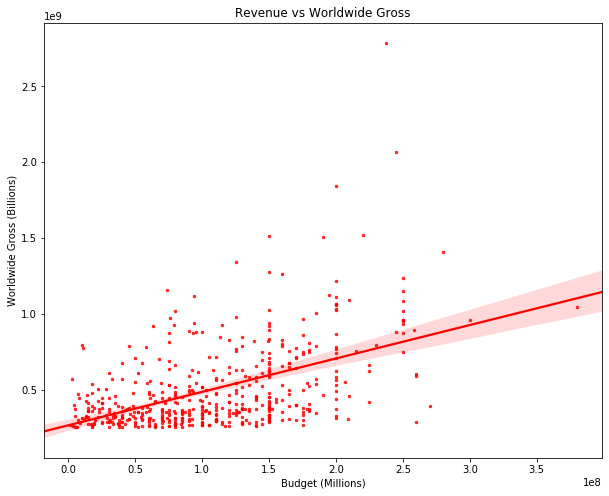

```python
plt1, ax = plt.subplots()
plt1.set_size_inches(10.0, 8.0)

#Create the regression plot
plt1 = sns.regplot(x="budget", y="worldwidegross", color = "red", scatter_kws={'s':6} ,data=data2).set_title("Revenue vs Worldwide Gross")
plt.xlabel("Budget (Millions)")
plt.ylabel("Worldwide Gross (Billions)")
plt1
```

## 4.1 What budget range has the most positive effect on movies?

In order to determine how budget could affect the success of a movie, we decided to make a bargraph that showed the average revenue based on different budget ranges. The budget ranges were \$50,000,000, \\$100,000,000, \$150,000,000, and \\$200,000,000.

It was evident that the budget range greater than \$200,000,000 had the highest average revenue while a budget range of less than \\$50,000,000 had the lowest average revenue. This makes sense because if people put higher budgeting on movies, then the quality of the movie would be better which would make it a more anticipated movie.

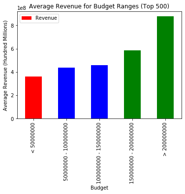

```python
# The grouping for Ratings and the respective Revenue set to 0
budget_range = [['< 50000000', 0],
           ['50000000 - 100000000', 0],
           ['100000000 - 150000000', 0],
            ['150000000 - 200000000', 0],
            ['> 200000000', 0]]
budgetRev = pd.DataFrame(budget_range, columns = ['Budget', 'Revenue'])
# Dictionary to keep track of the number of films per group
budget_num_groups = { '< 50000000' : 0,
                     '50000000 - 100000000' : 0,
                     '100000000 - 150000000' : 0,
                     '150000000 - 200000000' : 0,
                      '> 200000000' : 0 }

# Iterating through each row, adding the Revenue to the appropriate group
# Also incrementing the appropriate group in rating_num_groups
for i, j in data.iterrows():
    if (data['budget'][i] < 50000000):
        budgetRev.loc[budgetRev['Budget'] == '< 50000000', 'Revenue'] += data['worldwidegross'][i]
        budget_num_groups['< 50000000'] += 1
    elif (data['budget'][i] < 100000000):
        budgetRev.loc[budgetRev['Budget'] == '50000000 - 100000000', 'Revenue'] += data['worldwidegross'][i]
        budget_num_groups['50000000 - 100000000'] += 1
    elif (data['budget'][i] < 150000000):
        budgetRev.loc[budgetRev['Budget'] == '100000000 - 150000000', 'Revenue'] += data['worldwidegross'][i]
        budget_num_groups['100000000 - 150000000'] += 1
    elif (data['budget'][i] < 200000000):
        budgetRev.loc[budgetRev['Budget'] == '150000000 - 200000000', 'Revenue'] += data['worldwidegross'][i]
        budget_num_groups['150000000 - 200000000'] += 1
    else:
        budgetRev.loc[budgetRev['Budget'] == '> 200000000', 'Revenue'] += data['worldwidegross'][i]
        budget_num_groups['> 200000000'] += 1

# Dividing the total Revenue for each group by the number of movies
for group in budget_num_groups.keys():
    budgetRev.loc[budgetRev['Budget'] == group, 'Revenue'] /= budget_num_groups[group]

# Plotting a bar graph showing the average revenue per rating group
bar_colors = ['r', 'b', 'b', 'g', 'g']
budgetHist = budgetRev.plot.bar(x='Budget', y='Revenue', colors=bar_colors)
plt.title("Average Revenue for Budget Ranges (Top 500)")
plt.xlabel("Budget")
plt.ylabel("Average Revenue (Hundred Millions)")
```

# 5. Does runtime have a significant affect on total revenue?

By sorting the runtime and removing unnecessary columns, we could see that Gone with the Wind had the longest runtime with a $400,176,500 worldwide gross. To see if this was normal, we graphed this in the next section.

```python
data3 = data.sort_values(by='runtime', ascending=False)
data3 = data3[['title', 'runtime', 'worldwidegross']]
data3.head()
```

|  | title | runtime | worldwidegross |
| --- | --- | --- | --- |
| 242 | Gone with the Wind | 238.0 | 4.001765e+08 |
| 15 | The Lord of the Rings: The Return of the King | 201.0 | 1.118889e+09 |
| 357 | Schindler's List | 195.0 | 3.213656e+08 |
| 2 | Titanic | 194.0 | 1.845034e+09 |
| 436 | The Green Mile | 189.0 | 2.846000e+08 |

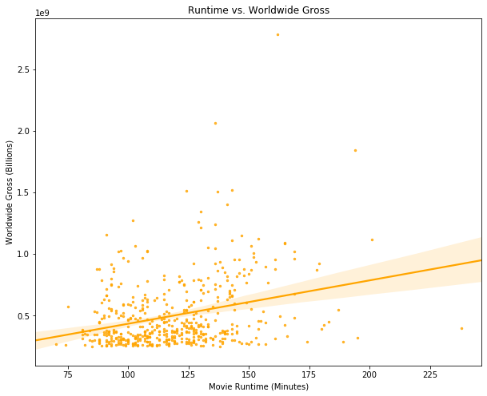

```python
# Plot runtime vs revenue
plt2, ax2 = plt.subplots()
plt2.set_size_inches(10.0, 8.0)

#Create the regression plot
runtimeplot = sns.regplot(x = 'runtime', y = 'worldwidegross', color = "orange", scatter_kws={'s':6}, data=data3).set_title("Runtime vs. Worldwide Gross")
plt.xlabel("Movie Runtime (Minutes)")
plt.ylabel("Worldwide Gross (Billions)")
runtimeplot
```

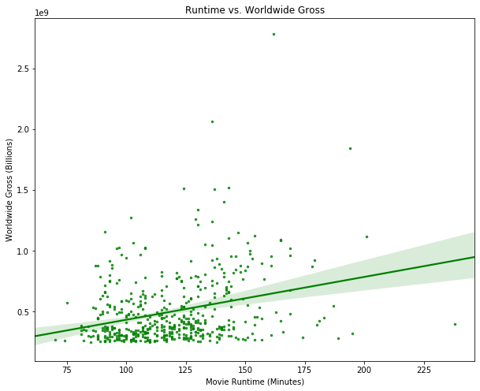

```python
newruntimeplot, ax2 = plt.subplots()
newruntimeplot.set_size_inches(10.0, 8.0)

#Create the regression plot
newruntimeplot = sns.regplot(x = 'runtime', y = 'worldwidegross', color = "green", scatter_kws={'s':6}, data=data3).set_title("Runtime vs. Worldwide Gross")
plt.xlabel("Movie Runtime (Minutes)")
plt.ylabel("Worldwide Gross (Billions)")
newruntimeplot
```

## 5.1 What runtimes have the most positive effect on movies?

To get a better idea of how the runtime may affect the success of a movie, we wanted to see the average revenue for different ranges of runtimes. We decided on 6 groups of runtime ranges, less than 90 minutes, between 90 and 105 minutes, between 105 and 120 minutes, between 120 and 135 minutes, between 135 and 150 minutes, and over 150 minutes.

We wanted a visual representation of this data, in the form of a bar graph.

First, we created a dataframe to store the revenue for each of the 6 respective ranges. Then, we created a dictionary to store a count for the number of films in each range (to calculate the average revenue later on)

Then, we iterated through each movie in the Top 500, added the revenue to the runtime range based on the runtime for that specific movie, and incremented the count for the appropriate runtime group too.

Afterwards, we iterated through each runtime group and divided the total revenue by the total number of movies in each group to get the average revenue for each runtime group.

Finally, we created a bar graph showing the average revenue for each runtime group and colored the least successful runtime group red and the most successful groups green.

[output not shown]

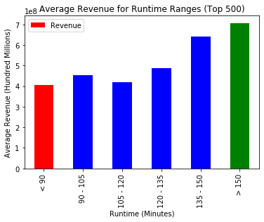

```python
# Creating a dataframe with Range and Revenue columns for specific runtimes with revenue set to 0
runtime_groups = [['< 90', 0],
           ['90 - 105', 0],
           ['105 - 120', 0],
            ['120 - 135', 0],
            ['135 - 150', 0],
            ['> 150', 0]]
runtimeRev = pd.DataFrame(runtime_groups, columns = ['Range', 'Revenue'])
# Creating a dictionary to keep track of the number of films in each runtime range gorup
runtime_num_groups = { '< 90' : 0,
                     '90 - 105' : 0,
                     '105 - 120' : 0,
                     '120 - 135' : 0,
                      '135 - 150' : 0,
                     '> 150' : 0}

# Iterating through the database and adding to the total revenue for each runtime group
# Also incrementing the number of movies in each appropriate group
for i, j in data.iterrows():
    if (data['runtime'][i] < 90):
        runtimeRev.loc[runtimeRev['Range'] == '< 90', 'Revenue'] += data['worldwidegross'][i]
        runtime_num_groups['< 90'] += 1
    elif (data['runtime'][i] < 105):
        runtimeRev.loc[runtimeRev['Range'] == '90 - 105', 'Revenue'] += data['worldwidegross'][i]
        runtime_num_groups['90 - 105'] += 1
    elif (data['runtime'][i] < 120):
        runtimeRev.loc[runtimeRev['Range'] == '105 - 120', 'Revenue'] += data['worldwidegross'][i]
        runtime_num_groups['105 - 120'] += 1
    elif (data['runtime'][i] < 135):
        runtimeRev.loc[runtimeRev['Range'] == '120 - 135', 'Revenue'] += data['worldwidegross'][i]
        runtime_num_groups['120 - 135'] += 1
    elif (data['runtime'][i] < 150):
        runtimeRev.loc[runtimeRev['Range'] == '135 - 150', 'Revenue'] += data['worldwidegross'][i]
        runtime_num_groups['135 - 150'] += 1
    else:
        runtimeRev.loc[runtimeRev['Range'] == '> 150', 'Revenue'] += data['worldwidegross'][i]
        runtime_num_groups['> 150'] += 1

# Dividing the total revenue for each runtime group by the number of films to retrieve the average
for group in runtime_num_groups.keys():
    runtimeRev.loc[runtimeRev['Range'] == group, 'Revenue'] /= runtime_num_groups[group]

# Creating a bar graph that shows the relationship between the runtime of movies and the average revenue
bar_colors = ['r', 'b', 'b', 'b', 'b', 'g']
runtimeHist = runtimeRev.plot.bar(x='Range', y='Revenue', color=bar_colors)
plt.title("Average Revenue for Runtime Ranges (Top 500)")
plt.xlabel("Runtime (Minutes)")
plt.ylabel("Average Revenue (Hundred Millions)")
```

# 6. Do genres significantly impact movie success?

A genre is a category characterized by similar features such as plot or theme. In this section, we try and see if a movies genre(s) have a significant impact on its success.. The genres present in the top 500 grossing movies include: Science Fiction, Action, Adventure, Fantasy, Thriller, Drama, Romance, Family, Animation, Crime, Comedy, Mystery, Music, Horror, War, Western, and History. While this is not an exhaustive list of possible movie genres, these are the only genres present in the top 500 and will be the ones we base our calculations on.

```python
data4 = data.sort_values(by='genre_value', ascending=False)
data4 = data4[['title', 'genre_value', 'worldwidegross']]
data4.head()
```

|  | title | genre_value | worldwidegross |
| --- | --- | --- | --- |
| 153 | Brave | 0.648752 | 538983207.0 |
| 123 | How to Train Your Dragon 2 | 0.648752 | 609123048.0 |
| 418 | G-Force | 0.585413 | 292817841.0 |
| 231 | Night at the Museum: Battle of the Smithsonian | 0.585413 | 413106170.0 |
| 135 | Night at the Museum | 0.585413 | 574480841.0 |

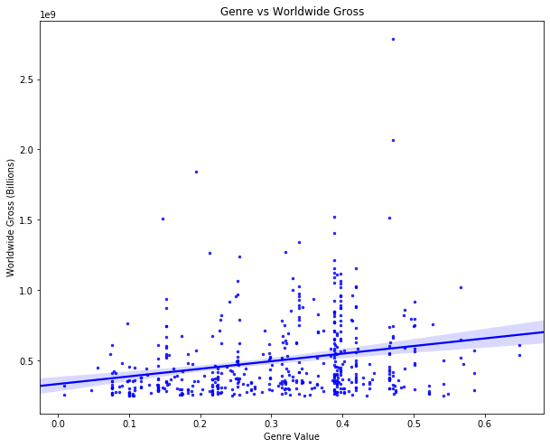

```python
plt2, ax2 = plt.subplots()
plt2.set_size_inches(10.0, 8.0)

#Create the regression plot
plt2 = sns.regplot(x="genre_value", y="worldwidegross", color = "blue", scatter_kws={'s':6} ,data=data4).set_title("Genre vs Worldwide Gross")
plt.xlabel("Genre Value")
plt.ylabel("Worldwide Gross (Billions)")
plt2
```

## 6.1 What genres have the most positive effect on movies?

To get a better idea of how the genre may affect the success of a movie, we wanted to see what the average revenue for each specfic genre was.

First, we created a dataframe with Genre and Revenue columns along with a dictionary with each individual genre (to later calculate the average revenue for each genre)

Then, we iterated through each Top 500 movie and added the revenue to each appropriate genre, incremented the number of movies in that genre, and finally found the average revenue for each genre.

Then we created a bar graph to show the average revenue for each of the genres. The least successful genre is shown in red and the most successful genres are shown in green.

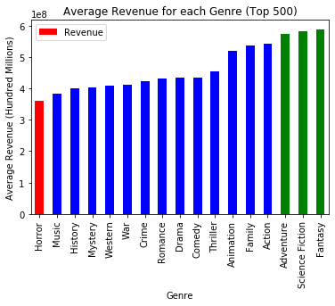

```python
# Creating a dataframe with columns for Genre and Revenue
# Each respective genre has revenue set to 0
revenues = [['Science Fiction', 0],
            ['Action', 0],
           ['Adventure', 0],
           ['Fantasy', 0],
           ['Thriller', 0],
           ['Drama', 0],
           ['Romance', 0],
           ['Family', 0],
           ['Animation', 0],
           ['Crime', 0],
           ['Comedy', 0],
           ['Mystery', 0],
           ['Music', 0],
           ['Horror', 0],
           ['War', 0],
           ['Western', 0],
           ['History', 0]]
genresRev = pd.DataFrame(revenues, columns = ['Genre', 'Revenue'])

# A dictionary to count the total number of films for each genre
genres_num_groups = { 'Science Fiction' : 0,
                     'Action' : 0,
                     'Adventure' : 0,
                     'Fantasy' : 0,
                      'Thriller' : 0,
                     'Drama' : 0,
                      'Romance' : 0,
                      'Family' : 0,
                      'Animation' : 0,
                      'Crime' : 0,
                      'Comedy' : 0,
                      'Mystery' : 0,
                      'Music' : 0,
                      'Horror' : 0,
                      'War' : 0,
                      'Western' : 0,
                      'History' : 0 }

# Iterating through the database and adding the revenue for each movie to every genre it is classified as
# Also incrementing the genre movie count
for i, j in data.iterrows():
    for genre in data['genres'][i]:
        genresRev.loc[genresRev['Genre'] == genre, 'Revenue'] += data['worldwidegross'][i]
        genres_num_groups[genre] += 1

# Dividing the total revenue for each genre by the number of movies in that genre
for genre in genres_num_groups.keys():
    genresRev.loc[genresRev['Genre'] == genre, 'Revenue'] /= genres_num_groups[genre]

# Plotting a bar graph to show the average revenue for each genre
genresRev = genresRev.sort_values(by=['Revenue'], ascending = True)
bar_colors = ['r', 'b', 'b', 'b', 'b', 'b', 'b', 'b', 'b', 'b', 'b', 'b', 'b', 'b', 'g', 'g', 'g']
genreHist = genresRev.plot.bar(x='Genre', y = 'Revenue', color=bar_colors)
plt.title("Average Revenue for each Genre (Top 500)")
plt.xlabel("Genre")
plt.ylabel("Average Revenue (Hundred Millions)")
```

Based on the bar graph shown above, we can see that there the genres with the highest average revenue are Adventure, Science Fiction, and Fantasy. Fantasy has the highest average revenue while horror has the lowest.

# 7. How do ratings effect a movies revenue?

```python
data5 = data.sort_values(by='vote_average', ascending=False)
data5 = data5[['title', 'vote_average', 'worldwidegross']]
data5.head()
```

|  | title | vote_average | worldwidegross |
| --- | --- | --- | --- |
| 357 | Schindler's List | 8.3 | 3.213656e+08 |
| 28 | The Dark Knight | 8.3 | 1.004558e+09 |
| 449 | Spirited Away | 8.3 | 2.749251e+08 |
| 218 | The Intouchables | 8.2 | 4.264809e+08 |
| 154 | The Empire Strikes Back | 8.2 | 5.384000e+08 |

[figure not shown]

```python
ratingplot, ax2 = plt.subplots()
ratingplot.set_size_inches(10.0, 8.0)

#Create the regression plot
ratingplot = sns.regplot(x = 'vote_average', y = 'worldwidegross', data=data5, color = "purple", scatter_kws={'s':6}).set_title("Rating vs. Worldwide Gross")
plt.xlabel("IMDb Rating (1 to 10)")
plt.ylabel("Worldwide Gross (Billions)")
```

[figure not shown]

```python
# Remove outliers
newratingplot, ax2 = plt.subplots()
newratingplot.set_size_inches(10.0, 8.0)

#Create the regression plot
nooutlierdata = data[data.worldwidegross < 1500000000]
newratingplot = sns.regplot(x = 'vote_average', y = 'worldwidegross', color = "indigo", scatter_kws={'s':6}, data=nooutlierdata).set_title("Rating vs. Worldwide Gross")
plt.xlabel("IMDb Rating (1 to 10)")
plt.ylabel("Worldwide Gross (Billions)")
newratingplot
```

## 7.1 What ratings have the most positive effect on movies?

We also wanted to explore if the ratings of a movie can tell us something about how much revenue the movie has received.

Similar to our runtime approach, we first separated the films into groups: Rating below 5, Rating between 5 and 6, Rating between 6 and 7, Rating between 7 and 8, Rating over 8. Then we created a dataframe with columns for Rating and Revenue. We iterated through each Top 500 movie and updated the dataframe appropriately, incremented the count for each rating range, then found the average revenue for each rating range.

Finally, we graphed the data and colored the least successful range red and the most successful ranges green.

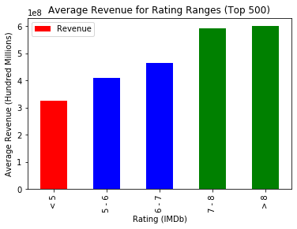

```python
# The grouping for Ratings and the respective Revenue set to 0
rating_groups = [['< 5', 0],
           ['5 - 6', 0],
           ['6 - 7', 0],
            ['7 - 8', 0],
            ['> 8', 0]]
ratingRev = pd.DataFrame(rating_groups, columns = ['Rating', 'Revenue'])

# Dictionary to keep track of the number of films per group
rating_num_groups = { '< 5' : 0,
                     '5 - 6' : 0,
                     '6 - 7' : 0,
                     '7 - 8' : 0,
                      '> 8' : 0 }

# Iterating through each row, adding the Revenue to the appropriate group
# Also incrementing the appropriate group in rating_num_groups
for i, j in data.iterrows():
    if (data['vote_average'][i] < 5):
        ratingRev.loc[ratingRev['Rating'] == '< 5', 'Revenue'] += data['worldwidegross'][i]
        rating_num_groups['< 5'] += 1
    elif (data['vote_average'][i] < 6):
        ratingRev.loc[ratingRev['Rating'] == '5 - 6', 'Revenue'] += data['worldwidegross'][i]
        rating_num_groups['5 - 6'] += 1
    elif (data['vote_average'][i] < 7):
        ratingRev.loc[ratingRev['Rating'] == '6 - 7', 'Revenue'] += data['worldwidegross'][i]
        rating_num_groups['6 - 7'] += 1
    elif (data['vote_average'][i] < 8):
        ratingRev.loc[ratingRev['Rating'] == '7 - 8', 'Revenue'] += data['worldwidegross'][i]
        rating_num_groups['7 - 8'] += 1
    else:
        ratingRev.loc[ratingRev['Rating'] == '> 8', 'Revenue'] += data['worldwidegross'][i]
        rating_num_groups['> 8'] += 1

# Dividing the total Revenue for each group by the number of movies
for group in rating_num_groups.keys():
    ratingRev.loc[ratingRev['Rating'] == group, 'Revenue'] /= rating_num_groups[group]

# Plotting a bar graph showing the average revenue per rating group
bar_colors = ['r', 'b', 'b', 'g', 'g']
ratingHist = ratingRev.plot.bar(x='Rating', y='Revenue', colors=bar_colors)
plt.title("Average Revenue for Rating Ranges (Top 500)")
plt.xlabel("Rating (IMDb)")
plt.ylabel("Average Revenue (Hundred Millions)")
```

The resulting bar graph above shows that higher rated movies tend to receive more revenue

# 8. What release months yield more successful movies?

Release month is the month that a movie is released in. We believe that release month may have a significant impact on the successfulness of a movie due to the fact that people go see movies at different rates throughout the year. For example, people tend to see movies more during the summer months as well as the holiday months as opposed to other months were school and work are more relevant. We look for this impact by, again, plotting month_value against worldwide gross.

```python
data6 = data.sort_values(by='month_value', ascending=False)
data6 = data6[['title', 'month_value', 'worldwidegross']]
data6.head()
```

|  | title | month_value | worldwidegross |
| --- | --- | --- | --- |
| 250 | Raiders of the Lost Ark | 0.34 | 389925971.0 |
| 337 | Now You See Me 2 | 0.34 | 334901337.0 |
| 147 | Mission: Impossible II | 0.34 | 546388105.0 |
| 148 | The Day After Tomorrow | 0.34 | 544272402.0 |
| 149 | X-Men: Apocalypse | 0.34 | 543934787.0 |

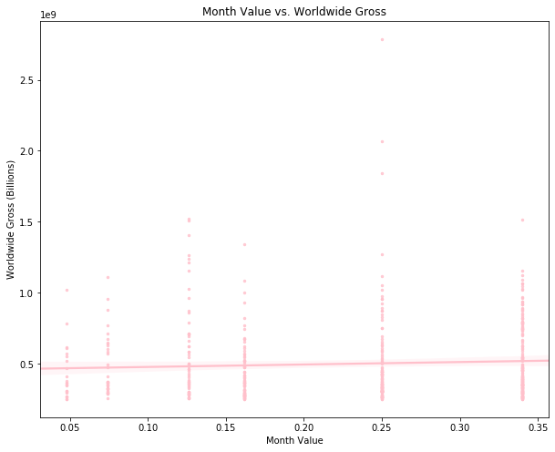

```python
plt3, ax3 = plt.subplots()
plt3.set_size_inches(10.0, 8.0)

#Create the regression plot
plt3 = sns.regplot(x = 'month_value', y = 'worldwidegross', data=data6, color = "pink", scatter_kws={'s':6}).set_title("Month Value vs. Worldwide Gross")
plt.xlabel("Month Value")
plt.ylabel("Worldwide Gross (Billions)")
```

## 8.1 What time of year has the most positive effect on movies?

Here we have the bins corresponding to each month and the number of the top 500 grossing movies that were released in each of them. Upon review, we can see that the summer months, mainly May and June, as well as the holiday months, November and December, seem to be the most fruitful times to release movies.

```python
#Print out the count of each month bin
count_month
for i in count_month:
    if i == 1:
        print(('January/February: ' + str(count_month[i])))
    elif i == 2:
        print(('March/April: ' + str(count_month[i])))
    elif i == 3:
        print(('May/June: ' + str(count_month[i])))
    elif i == 4:
        print(('July/August: ' + str(count_month[i])))
    elif i == 5:
        print(('September/October: ' + str(count_month[i])))
    elif i == 6:
        print(('November/December ' + str(count_month[i])))
```

```
January/February: 24
March/April: 63
May/June: 170
July/August: 81
September/October: 37
November/December 125
```

# 9. Can we build an accurate model that accurately predicts a movies' success?

Now that we have analyzed the impact each one of our key factors has on a movies' success, we must choose which ones we want to include in our predictive model. The way we will determine inclusion is by analyzing each factors [Pearson's Correlation Coefficient](https://mathbits.com/MathBits/TISection/Statistics2/correlation.htm).

```python
print("Correlation Coefficients")
print("Budget: " + str(np.corrcoef(data['budget'].values, data['worldwidegross'].values)[0][1]))
print("Runtime: " + str(np.corrcoef(data['runtime'].values, data['worldwidegross'].values)[0][1]))
print("Vote Average: " + str(np.corrcoef(data['vote_average'].values, data['worldwidegross'].values)[0][1]))
print("Genre: " + str(np.corrcoef(data['genre_value'].values, data['worldwidegross'].values)[0][1]))
print("Month of Release: " + str(np.corrcoef(data['month_value'].values, data['worldwidegross'].values)[0][1]))
```

```
Correlation Coefficients
Budget: 0.5063102465083876
Runtime: 0.2916350607741925
Vote Average: 0.2635185304123004
Genre: 0.2474950513178972
Month of Release: 0.06080397420657298
```

The correlation coefficients for budget, runtime, vote average, and genre are all at least weakly, positively correlated so we will include them in our multiple linear regression. Month of release, on the other hand, has almost no correlation so we will leave it out of our model.

Next we train our data using sklearn's LinearRegression() function and obtain coefficients for each of our factors. In our regression equation, "a" corresponds to budget, "b" corresponds to runtime, "c" corresponds to vote_average, and "d" corresponds to genre_value.

```python
#Dependent variables
X = data[['budget', 'runtime', 'vote_average', 'genre_value']]
#Independent variable
y = data[['worldwidegross']]
#Train and fit the model
lm = linear_model.LinearRegression()
model = lm.fit(X,y)
coefficients = lm.coef_
print('Regression Equation = ' + str(coefficients[0][0]) + 'a + ' + str(coefficients[0][1]) + 'b + ' + str(coefficients[0][2]) + 'c + ' + str(coefficients[0][3]) + 'd')
print('R^2 Value = ' + str(lm.score(X,y)))
```

```
Regression Equation = 2.0915844198249762a + 1015338.5851081708b + 114865161.33975784c + 195405753.38673532d
R^2 Value = 0.3685465460244114
```

We now analyze our [R^2 value](https://statisticsbyjim.com/regression/interpret-r-squared-regression/). This value is on the lower side and might indicate that our model isn't amazingly accurate. We can further analyze the accuracy of our multiple linear regression by looking at the residual plot.

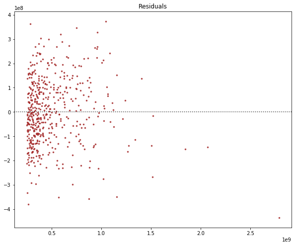

```python
plt3, ax = plt.subplots()
plt3.set_size_inches(10.0, 8.0)

#Obtain the predictions from our multiple linear regression model
predictions = lm.predict(X)

#Create the residual plot
plt3 = sns.residplot(y.values, predictions,color = "brown",scatter_kws={'s':6} ).set_title("Residuals")
```

Here we can see that our residual data is unablanced on the X axis. According to this [article](http://docs.statwing.com/interpreting-residual-plots-to-improve-your-regression/#large-axis-header) on Statwing, this indicates that we may either need to add an explanatory variable or may be missing a variable all together. Due to the nature of the data we are analyzing, we believe that it is more likely that we are missing a varaiable all together because with movies, there are many ambiguous characteristics that can't be easily documented.

# Conclusion

Based on the results of our analysis, we discovered several common trends among the top 500 movies. To reiterate, we found that having large budgets, large being defined as in excess of \$200,000,000, had the most positive impact on movie success. Then, having runtimes of over 135 minutes, genres of adventure, science fiction, and fantasy, and a voting average of over 7 had moderate effects on movie revenue. Then finally, we discovered that although most of the top 500 movies were released in May/June or November/December, there was no significant correlation between movie release date and movie success. However, these are far from the only factors that go into a successful movie which was evident when we tried to create a movie successfulness predictive model. This model produced mediocre predictions, resulting in skewed predicted data that could be explained by some other unexplored or unanalyzed variables. While we hoped to be able to create a more accurate regression model, the factors that define movie success proved to be more ambiguous than the surface level factors that most people, including ourselves, think about and could be an interesting area to revisit for further analysis in the future.